# ANOVA test for coesao

Geiser C. Challco geiser@alumni.usp.br

- ANOVA: coesao ~ time
  - Data Preparation
  - Summary Statistics
  - ANOVA Computation
  - PairWise Computation
- ANOVA: coesao ~ time*gender + Error(id/time)
  - Data Preparation
    - Check assumptions: Identifying Outliers
    - Check assumptions: Normality Test
    - Summary Statistics
  - ANOVA Computation
  - ANOVA Computation after removing non.normal data
  - PairWise Computation
  - PairWise Computation after removing non.normal data
- ANOVA: coesao ~ time*localizacao + Error(id/time)
  - Data Preparation
    - Check assumptions: Identifying Outliers
    - Check assumptions: Normality Test
    - Summary Statistics
  - ANOVA Computation
  - ANOVA Computation after removing non.normal data
  - PairWise Computation
  - PairWise Computation after removing non.normal data
- ANOVA: coesao ~ time*regiao + Error(id/time)
  - Data Preparation
    - Check assumptions: Identifying Outliers
    - Check assumptions: Normality Test
    - Summary Statistics
  - ANOVA Computation
  - ANOVA Computation after removing non.normal data
  - PairWise Computation
  - PairWise Computation after removing non.normal data
- ANOVA: coesao ~ time*porte + Error(id/time)
  - Data Preparation
    - Check assumptions: Identifying Outliers
    - Check assumptions: Normality Test
    - Summary Statistics
  - ANOVA Computation
  - ANOVA Computation after removing non.normal data
  - PairWise Computation
  - PairWise Computation after removing non.normal data

```r
dat <- read_excel("../data/data.xlsx", sheet = "alunos_ef59")

escolas <- read_excel("../data/data.xlsx", sheet = "escolas")
edat <- merge(dat, escolas, by = "cod_escola", all.x = T)
```

# ANOVA: coesao ~ time

## Data Preparation

```r
data <- edat[,c("aluno_id","ciclo","coesao")]
data <- data[data$ciclo %in% c("Segundo Ciclo","Terceiro Ciclo"),]
data$ciclo <- factor(data$ciclo, c("Segundo Ciclo","Terceiro Ciclo"))
data <- unique(data)

wdat <- spread(data, ciclo, coesao)
wdat <- wdat[complete.cases(wdat),]
colnames(wdat) <- c("id","c2","c3")

ldat <- gather(wdat, key = time, value = coesao, c2,c3) %>%
  convert_as_factor(id, time)
ldat <- rshinystatistics::remove_group_data(ldat, "coesao", "time", n.limit = 30)
```

## Summary Statistics

```r
(sdat <- ldat %>% group_by(time) %>%
   get_summary_stats(coesao, type = "mean_sd"))
```

```
## # A tibble: 2 × 5
##   time  variable     n  mean    sd
##   <fct> <fct>    <dbl> <dbl> <dbl>
## 1 c2    coesao    4042  2.36 0.508
## 2 c3    coesao    4042  2.36 0.546
```

| time | variable | n | mean | sd |
| --- | --- | --- | --- | --- |
| c2 | coesao | 4042 | 2.362 | 0.508 |
| c3 | coesao | 4042 | 2.357 | 0.546 |

## ANOVA Computation

```r
(res.aov <- anova_test(ldat, dv = coesao, wid = id, within = time))
```

```
## ANOVA Table (type III tests)
##
##   Effect DFn  DFd     F     p p<.05   ges
## 1   time   1 4041 0.182 0.669       2e-05
```

## PairWise Computation

```r
(pwc <- ldat %>% emmeans_test(coesao ~ time, detailed = T, p.adjust.method = "bonferroni"))
```

```
## # A tibble: 1 × 14
##   term  .y.    group1 group2 null.value estimate     se    df conf.low conf.high
## * <chr> <chr>  <chr>  <chr>       <dbl>    <dbl>  <dbl> <dbl>    <dbl>     <dbl>
## 1 time  coesao c2     c3              0  0.00472 0.0117  8082  -0.0183    0.0277
## # ℹ 4 more variables: statistic <dbl>, p <dbl>, p.adj <dbl>, p.adj.signif <chr>
```

| term | .y. | group1 | group2 | null.value | estimate | se | df | conf.low | conf.high | statistic | p | p.adj | p.adj.signif |
| --- | --- | --- | --- | --- | --- | --- | --- | --- | --- | --- | --- | --- | --- |
| time | coesao | c2 | c3 | 0 | 0.005 | 0.012 | 8082 | -0.018 | 0.028 | 0.402 | 0.687 | 0.687 | ns |

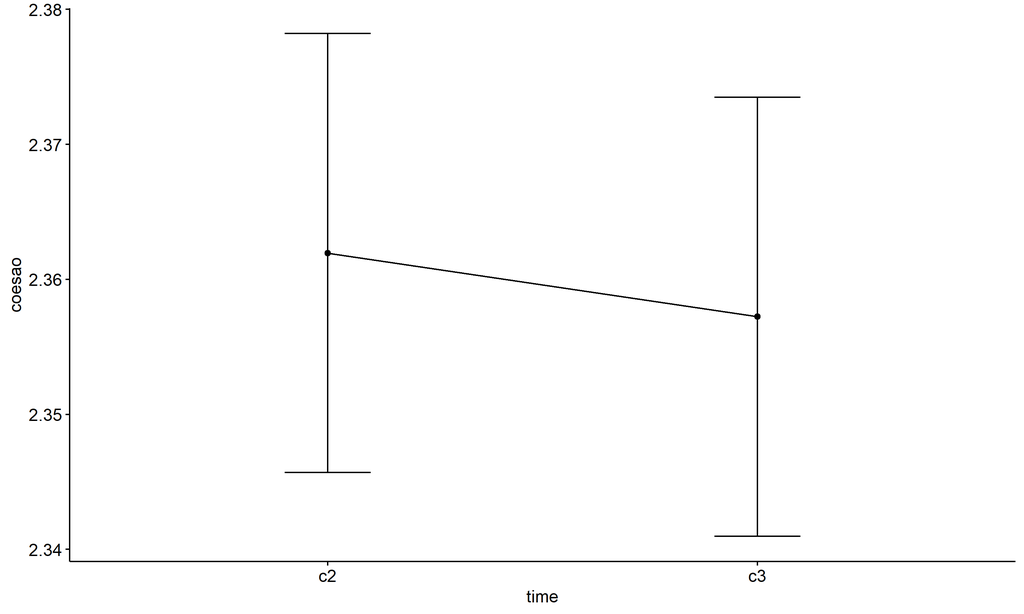

```r
pwc <- add_xy_position(pwc, x = "time", fun = "mean_se")
ggline(get_emmeans(pwc), x = "time", y = "emmean", ylab = "coesao") +
  geom_errorbar(aes(ymin = conf.low, ymax = conf.high), width = 0.2) +
  stat_pvalue_manual(pwc, hide.ns = T, tip.length = F)
```

# ANOVA: coesao ~ time*gender + Error(id/time)

## Data Preparation

```r
data <- edat[,c("aluno_id","gender","ciclo","coesao")]
data <- data[data$ciclo %in% c("Segundo Ciclo","Terceiro Ciclo"),]
data$ciclo <- factor(data$ciclo, c("Segundo Ciclo","Terceiro Ciclo"))
data <- unique(data)

wdat <- spread(data, ciclo, coesao)
wdat <- wdat[complete.cases(wdat),]
colnames(wdat) <- c("id","gender","c2","c3")

ldat <- gather(wdat, key = time, value = coesao, c2,c3) %>%
  convert_as_factor(id, time)
ldat <- remove_group_data(ldat, "coesao", c("time", "gender"), n.limit = 30)
ldat$gender <- factor(ldat$gender, sort(unique(ldat$gender)))
```

### Check assumptions: Identifying Outliers

```r
outliers <- identify_outliers(group_by(ldat, time, gender), coesao)
(outliers <- outliers[outliers$is.extreme == T,])
```

```
## [1] gender     time       id         coesao     is.outlier is.extreme
## <0 rows> (or 0-length row.names)
```

| gender | time | id | coesao | is.outlier | is.extreme |
| --- | --- | --- | --- | --- | --- |

### Check assumptions: Normality Test

```r
(normality.df <- normality.test.per.groups(ldat, "coesao", c("time", "gender")))
```

```
##      var variable time gender    n   skewness   kurtosis symmetry statistic
## 1 coesao   coesao   c2 Female 1876 -0.2197488 -0.2488704      YES 20.709430
## 2 coesao   coesao   c2   Male 1917 -0.1301207 -0.1510535      YES  7.247789
## 3 coesao   coesao   c3 Female 1876 -0.2196073 -0.3675159      YES 30.085025
## 4 coesao   coesao   c3   Male 1917 -0.2300900 -0.4474931      YES 42.683529
##       method            p p.signif normality
## 1 D'Agostino 3.184229e-05      ***         -
## 2 D'Agostino 2.667857e-02       ns         -
## 3 D'Agostino 2.931701e-07     ****         -
## 4 D'Agostino 5.387527e-10     ****         -
```

| var | variable | time | gender | n | skewness | kurtosis | symmetry | statistic | method | p | p.signif | normality |
| --- | --- | --- | --- | --- | --- | --- | --- | --- | --- | --- | --- | --- |
| coesao | coesao | c2 | Female | 1876 | -0.22 | -0.249 | YES | 20.709 | D’Agostino | 0.000 | *** | - |
| coesao | coesao | c2 | Male | 1917 | -0.13 | -0.151 | YES | 7.248 | D’Agostino | 0.027 | ns | - |
| coesao | coesao | c3 | Female | 1876 | -0.22 | -0.368 | YES | 30.085 | D’Agostino | 0.000 | **** | - |
| coesao | coesao | c3 | Male | 1917 | -0.23 | -0.447 | YES | 42.684 | D’Agostino | 0.000 | **** | - |

```r
(non.ids <- unique(do.call(
  c, lapply(which(normality.df$normality == 'NO'), FUN = function(i) {
  idx = which(ldat$time == normality.df$time[i] &
                ldat$gender == normality.df$gender[i])
  getNonNormal(ldat$"coesao"[idx], ldat$id[idx])
}))))
```

```r
if (length(non.ids) > 0)
  ldat2 <- ldat[!ldat$id %in% non.ids,]
```

### Summary Statistics

```r
(sdat <- ldat %>% group_by(time, gender) %>%
   get_summary_stats(coesao, type = "mean_sd"))
```

```
## # A tibble: 4 × 6
##   gender time  variable     n  mean    sd
##   <fct>  <fct> <fct>    <dbl> <dbl> <dbl>
## 1 Female c2    coesao    1876  2.39 0.518
## 2 Male   c2    coesao    1917  2.33 0.496
## 3 Female c3    coesao    1876  2.37 0.555
## 4 Male   c3    coesao    1917  2.34 0.54
```

| gender | time | variable | n | mean | sd |
| --- | --- | --- | --- | --- | --- |
| Female | c2 | coesao | 1876 | 2.390 | 0.518 |
| Male | c2 | coesao | 1917 | 2.329 | 0.496 |
| Female | c3 | coesao | 1876 | 2.373 | 0.555 |
| Male | c3 | coesao | 1917 | 2.338 | 0.540 |

```r
if (length(non.ids) > 0)
  (sdat <- ldat2 %>% group_by(time, gender) %>%
      get_summary_stats(coesao, type = "mean_sd"))
```

| gender | time | variable | n | mean | sd |
| --- | --- | --- | --- | --- | --- |
| Female | c2 | coesao | 1876 | 2.390 | 0.518 |
| Male | c2 | coesao | 1917 | 2.329 | 0.496 |
| Female | c3 | coesao | 1876 | 2.373 | 0.555 |
| Male | c3 | coesao | 1917 | 2.338 | 0.540 |

## ANOVA Computation

```r
(res.aov <- anova_test(ldat, dv = coesao, wid = id, between = gender, within = time))
```

```
## ANOVA Table (type III tests)
##
##        Effect DFn  DFd      F        p p<.05      ges
## 1      gender   1 3791 14.149 0.000171     * 2.00e-03
## 2        time   1 3791  0.147 0.701000       1.74e-05
## 3 gender:time   1 3791  1.259 0.262000       1.49e-04
```

## ANOVA Computation after removing non.normal data

```r
if (length(non.ids) > 0)
  (res.aov2 <- anova_test(ldat2, dv = coesao, wid = id, between = gender , within = time))
```

## PairWise Computation

```r
(pwc <- ldat %>% group_by(time) %>%
   emmeans_test(coesao ~ gender, detailed = T, p.adjust.method = "bonferroni"))
```

```
## # A tibble: 2 × 15
##   time  term   .y.    group1 group2 null.value estimate     se    df conf.low
## * <fct> <chr>  <chr>  <chr>  <chr>       <dbl>    <dbl>  <dbl> <dbl>    <dbl>
## 1 c2    gender coesao Female Male            0   0.0608 0.0171  7582  0.0272
## 2 c3    gender coesao Female Male            0   0.0351 0.0171  7582  0.00145
## # ℹ 5 more variables: conf.high <dbl>, statistic <dbl>, p <dbl>, p.adj <dbl>,
## #   p.adj.signif <chr>
```

| time | term | .y. | group1 | group2 | null.value | estimate | se | df | conf.low | conf.high | statistic | p | p.adj | p.adj.signif |
| --- | --- | --- | --- | --- | --- | --- | --- | --- | --- | --- | --- | --- | --- | --- |
| c2 | gender | coesao | Female | Male | 0 | 0.061 | 0.017 | 7582 | 0.027 | 0.094 | 3.546 | 0.000 | 0.000 | *** |
| c3 | gender | coesao | Female | Male | 0 | 0.035 | 0.017 | 7582 | 0.001 | 0.069 | 2.045 | 0.041 | 0.041 | * |

```r
(emms <- get_emmeans(pwc))
```

```
## # A tibble: 4 × 8
##   time  gender emmean     se    df conf.low conf.high method
##   <fct> <fct>   <dbl>  <dbl> <dbl>    <dbl>     <dbl> <chr>
## 1 c2    Female   2.39 0.0122  7582     2.37      2.41 Emmeans test
## 2 c2    Male     2.33 0.0121  7582     2.31      2.35 Emmeans test
## 3 c3    Female   2.37 0.0122  7582     2.35      2.40 Emmeans test
## 4 c3    Male     2.34 0.0121  7582     2.31      2.36 Emmeans test
```

| time | gender | emmean | se | df | conf.low | conf.high | method |
| --- | --- | --- | --- | --- | --- | --- | --- |
| c2 | Female | 2.390 | 0.012 | 7582 | 2.366 | 2.414 | Emmeans test |
| c2 | Male | 2.329 | 0.012 | 7582 | 2.306 | 2.353 | Emmeans test |
| c3 | Female | 2.373 | 0.012 | 7582 | 2.349 | 2.397 | Emmeans test |
| c3 | Male | 2.338 | 0.012 | 7582 | 2.314 | 2.362 | Emmeans test |

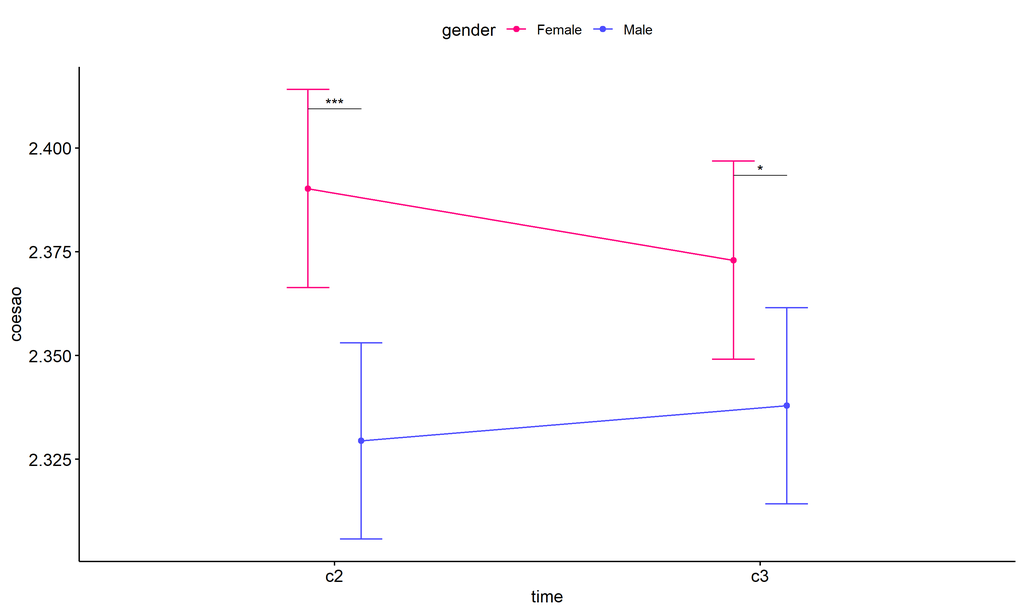

```r
pwc <- add_xy_position(pwc, x = "time", fun = "mean_se", dodge = 0.25)
pd <- position_dodge(width = 0.25)
ggline(emms, x = "time", y = "emmean", color = "gender",
       palette = c("#FF007F","#4D4DFF"),
       position = pd, ylab = "coesao") +
  geom_errorbar(aes(ymin = conf.low, ymax = conf.high, color = gender),
                position = pd, width = 0.2) +
  stat_pvalue_manual(pwc, hide.ns = T, tip.length = F, linetype = 1)
```

```r
(pwc <- ldat %>% group_by(gender) %>%
    emmeans_test(coesao ~ time, detailed = T, p.adjust.method = "bonferroni"))
```

```
## # A tibble: 2 × 15
##   gender term  .y.    group1 group2 null.value estimate     se    df conf.low
## * <fct>  <chr> <chr>  <chr>  <chr>       <dbl>    <dbl>  <dbl> <dbl>    <dbl>
## 1 Female time  coesao c2     c3              0  0.0173  0.0172  7582  -0.0165
## 2 Male   time  coesao c2     c3              0 -0.00847 0.0171  7582  -0.0419
## # ℹ 5 more variables: conf.high <dbl>, statistic <dbl>, p <dbl>, p.adj <dbl>,
## #   p.adj.signif <chr>
```

| gender | term | .y. | group1 | group2 | null.value | estimate | se | df | conf.low | conf.high | statistic | p | p.adj | p.adj.signif |
| --- | --- | --- | --- | --- | --- | --- | --- | --- | --- | --- | --- | --- | --- | --- |
| Female | time | coesao | c2 | c3 | 0 | 0.017 | 0.017 | 7582 | -0.017 | 0.051 | 1.002 | 0.316 | 0.316 | ns |
| Male | time | coesao | c2 | c3 | 0 | -0.008 | 0.017 | 7582 | -0.042 | 0.025 | -0.497 | 0.619 | 0.619 | ns |

```r
(emms <- get_emmeans(pwc))
```

```
## # A tibble: 4 × 8
##   gender time  emmean     se    df conf.low conf.high method
##   <fct>  <fct>  <dbl>  <dbl> <dbl>    <dbl>     <dbl> <chr>
## 1 Female c2      2.39 0.0122  7582     2.37      2.41 Emmeans test
## 2 Female c3      2.37 0.0122  7582     2.35      2.40 Emmeans test
## 3 Male   c2      2.33 0.0121  7582     2.31      2.35 Emmeans test
## 4 Male   c3      2.34 0.0121  7582     2.31      2.36 Emmeans test
```

| gender | time | emmean | se | df | conf.low | conf.high | method |
| --- | --- | --- | --- | --- | --- | --- | --- |
| Female | c2 | 2.390 | 0.012 | 7582 | 2.366 | 2.414 | Emmeans test |
| Female | c3 | 2.373 | 0.012 | 7582 | 2.349 | 2.397 | Emmeans test |
| Male | c2 | 2.329 | 0.012 | 7582 | 2.306 | 2.353 | Emmeans test |
| Male | c3 | 2.338 | 0.012 | 7582 | 2.314 | 2.362 | Emmeans test |

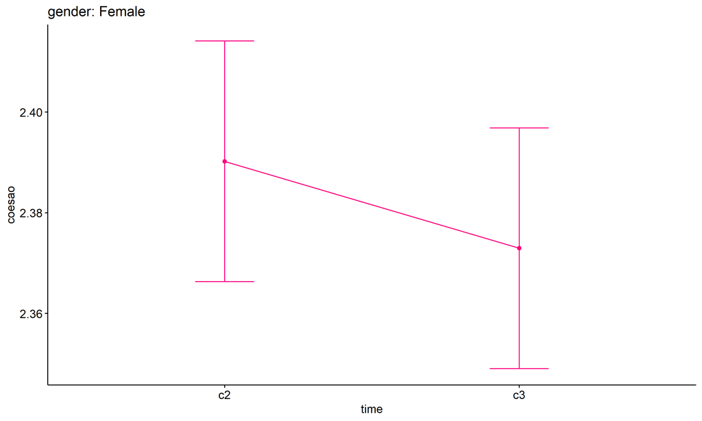

```r
emms.gg <- emms[which(emms$gender == "Female"),]
if (nrow(emms.gg) > 0)
  ggline(emms.gg, x = "time", y = "emmean", color = "#FF007F", ylab = "coesao") +
    geom_errorbar(aes(ymin = conf.low, ymax = conf.high),
                  width = 0.2, color = "#FF007F") +
    stat_pvalue_manual(
      add_xy_position(pwc[which(pwc$gender == "Female"),],
                      x = "time", fun = "mean_se"),
      hide.ns = T, color = "#FF007F", tip.length = F) +
    labs(title = "gender: Female")+
    theme(legend.text = element_blank())
```

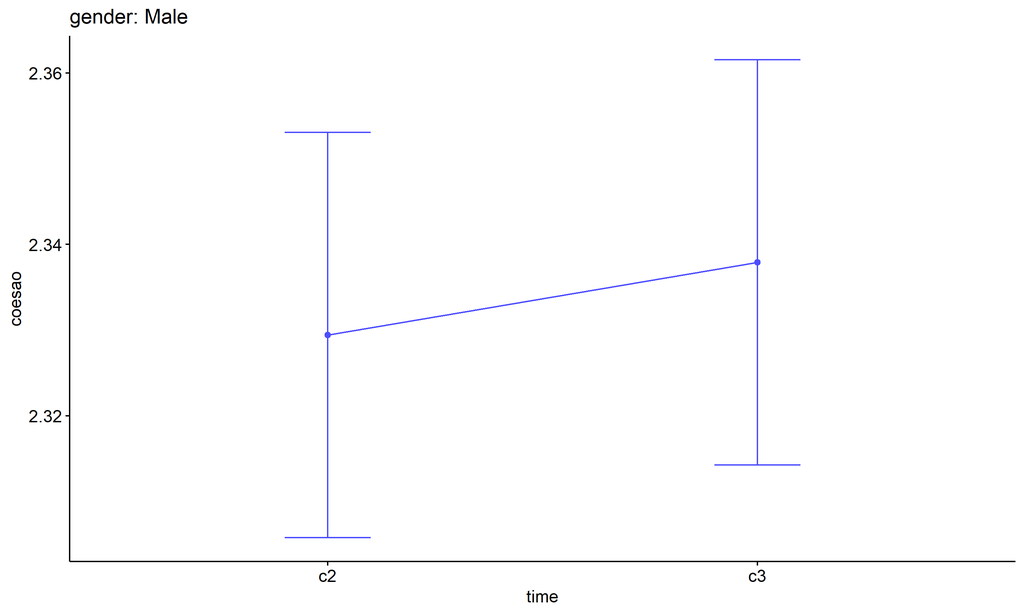

```r
emms.gg <- emms[which(emms$gender == "Male"),]
if (nrow(emms.gg) > 0)
  ggline(emms.gg, x = "time", y = "emmean", color = "#4D4DFF", ylab = "coesao") +
    geom_errorbar(aes(ymin = conf.low, ymax = conf.high),
                  width = 0.2, color = "#4D4DFF") +
    stat_pvalue_manual(
      add_xy_position(pwc[which(pwc$gender == "Male"),],
                      x = "time", fun = "mean_se"),
      hide.ns = T, color = "#4D4DFF", tip.length = F) +
    labs(title = "gender: Male")+
    theme(legend.text = element_blank())
```

## PairWise Computation after removing non.normal data

```r
if (length(non.ids) > 0)
  (pwc2 <- ldat2 %>% group_by(time) %>%
     emmeans_test(coesao ~ gender, detailed = T, p.adjust.method = "bonferroni"))
```

```r
if (length(non.ids) > 0)
  (emms2 <- get_emmeans(pwc2))
```

```r
if (length(non.ids) > 0) {
  pwc2 <- add_xy_position(pwc2, x = "time", fun = "mean_se", dodge = 0.25)
  pd2 <- position_dodge(width = 0.25)

  ggline(emms2, x = "time", y = "emmean", color = "gender",
         palette = c("#FF007F","#4D4DFF"),
         position = pd, ylab = "coesao") +
    geom_errorbar(aes(ymin = conf.low, ymax = conf.high, color = gender),
                position = pd, width = 0.2) +
    stat_pvalue_manual(pwc2, hide.ns = T, tip.length = F, linetype = 1)
}
```

```r
if (length(non.ids) > 0)
  (pwc2 <- ldat2 %>% group_by(gender) %>%
     emmeans_test(coesao ~ time, detailed = T, p.adjust.method = "bonferroni"))
```

```r
if (length(non.ids) > 0)
  (emms2 <- get_emmeans(pwc2))
```

```r
if (length(non.ids) > 0) {
  emms.gg <- emms2[which(emms2$gender == "Female"),]
  if (nrow(emms.gg) > 0)
    ggline(emms.gg, x = "time", y = "emmean", color = "#FF007F", ylab = "coesao") +
    geom_errorbar(aes(ymin = conf.low, ymax = conf.high),
                  width = 0.2, color = "#FF007F") +
    stat_pvalue_manual(
      add_xy_position(pwc[which(pwc$gender == "Female"),],
                      x = "time", fun = "mean_se"),
      hide.ns = T, color = "#FF007F", tip.length = F) +
    labs(title = "gender: Female") +
    theme(legend.text = element_blank())
}
```

```r
if (length(non.ids) > 0) {
  emms.gg <- emms2[which(emms2$gender == "Male"),]
  if (nrow(emms.gg) > 0)
    ggline(emms.gg, x = "time", y = "emmean", color = "#4D4DFF", ylab = "coesao") +
    geom_errorbar(aes(ymin = conf.low, ymax = conf.high),
                  width = 0.2, color = "#4D4DFF") +
    stat_pvalue_manual(
      add_xy_position(pwc[which(pwc$gender == "Male"),],
                      x = "time", fun = "mean_se"),
      hide.ns = T, color = "#4D4DFF", tip.length = F) +
    labs(title = "gender: Male") +
    theme(legend.text = element_blank())
}
```

# ANOVA: coesao ~ time*localizacao + Error(id/time)

## Data Preparation

```r
data <- edat[,c("aluno_id","localizacao","ciclo","coesao")]
data <- data[data$ciclo %in% c("Segundo Ciclo","Terceiro Ciclo"),]
data$ciclo <- factor(data$ciclo, c("Segundo Ciclo","Terceiro Ciclo"))
data <- unique(data)

wdat <- spread(data, ciclo, coesao)
wdat <- wdat[complete.cases(wdat),]
colnames(wdat) <- c("id","localizacao","c2","c3")

ldat <- gather(wdat, key = time, value = coesao, c2,c3) %>%
  convert_as_factor(id, time)
ldat <- remove_group_data(ldat, "coesao", c("time", "localizacao"), n.limit = 30)
ldat$localizacao <- factor(ldat$localizacao, sort(unique(ldat$localizacao)))
```

### Check assumptions: Identifying Outliers

```r
outliers <- identify_outliers(group_by(ldat, time, localizacao), coesao)
(outliers <- outliers[outliers$is.extreme == T,])
```

```
## [1] localizacao time        id          coesao      is.outlier  is.extreme
## <0 rows> (or 0-length row.names)
```

| localizacao | time | id | coesao | is.outlier | is.extreme |
| --- | --- | --- | --- | --- | --- |

### Check assumptions: Normality Test

```r
(normality.df <- normality.test.per.groups(ldat, "coesao", c("time", "localizacao")))
```

```
##      var variable time localizacao    n   skewness   kurtosis symmetry
## 1 coesao   coesao   c2       Rural  701 -0.1793122 -0.2357631      YES
## 2 coesao   coesao   c2      Urbana 3341 -0.1597006 -0.2250926      YES
## 3 coesao   coesao   c3       Rural  701 -0.1494830 -0.5187326      YES
## 4 coesao   coesao   c3      Urbana 3341 -0.2332760 -0.4015199      YES
##   statistic     method            p p.signif normality
## 1  5.410342 D'Agostino 6.685888e-02       ns         -
## 2 22.618061 D'Agostino 1.226169e-05      ***         -
## 3 16.001257 D'Agostino 3.352519e-04       **         -
## 4 64.493142 D'Agostino 9.880985e-15     ****         -
```

| var | variable | time | localizacao | n | skewness | kurtosis | symmetry | statistic | method | p | p.signif | normality |
| --- | --- | --- | --- | --- | --- | --- | --- | --- | --- | --- | --- | --- |
| coesao | coesao | c2 | Rural | 701 | -0.179 | -0.236 | YES | 5.410 | D’Agostino | 0.067 | ns | - |
| coesao | coesao | c2 | Urbana | 3341 | -0.160 | -0.225 | YES | 22.618 | D’Agostino | 0.000 | *** | - |
| coesao | coesao | c3 | Rural | 701 | -0.149 | -0.519 | YES | 16.001 | D’Agostino | 0.000 | ** | - |
| coesao | coesao | c3 | Urbana | 3341 | -0.233 | -0.402 | YES | 64.493 | D’Agostino | 0.000 | **** | - |

```r
(non.ids <- unique(do.call(
  c, lapply(which(normality.df$normality == 'NO'), FUN = function(i) {
  idx = which(ldat$time == normality.df$time[i] &
                ldat$localizacao == normality.df$localizacao[i])
  getNonNormal(ldat$"coesao"[idx], ldat$id[idx])
}))))
```

```r
if (length(non.ids) > 0)
  ldat2 <- ldat[!ldat$id %in% non.ids,]
```

### Summary Statistics

```r
(sdat <- ldat %>% group_by(time, localizacao) %>%
   get_summary_stats(coesao, type = "mean_sd"))
```

```
## # A tibble: 4 × 6
##   localizacao time  variable     n  mean    sd
##   <fct>       <fct> <fct>    <dbl> <dbl> <dbl>
## 1 Rural       c2    coesao     701  2.37 0.539
## 2 Urbana      c2    coesao    3341  2.36 0.501
## 3 Rural       c3    coesao     701  2.36 0.536
## 4 Urbana      c3    coesao    3341  2.36 0.548
```

| localizacao | time | variable | n | mean | sd |
| --- | --- | --- | --- | --- | --- |
| Rural | c2 | coesao | 701 | 2.369 | 0.539 |
| Urbana | c2 | coesao | 3341 | 2.360 | 0.501 |
| Rural | c3 | coesao | 701 | 2.360 | 0.536 |
| Urbana | c3 | coesao | 3341 | 2.357 | 0.548 |

```r
if (length(non.ids) > 0)
  (sdat <- ldat2 %>% group_by(time, localizacao) %>%
      get_summary_stats(coesao, type = "mean_sd"))
```

| localizacao | time | variable | n | mean | sd |
| --- | --- | --- | --- | --- | --- |
| Rural | c2 | coesao | 701 | 2.369 | 0.539 |
| Urbana | c2 | coesao | 3341 | 2.360 | 0.501 |
| Rural | c3 | coesao | 701 | 2.360 | 0.536 |
| Urbana | c3 | coesao | 3341 | 2.357 | 0.548 |

## ANOVA Computation

```r
(res.aov <- anova_test(ldat, dv = coesao, wid = id, between = localizacao, within = time))
```

```
## ANOVA Table (type III tests)
##
##             Effect DFn  DFd     F     p p<.05      ges
## 1      localizacao   1 4040 0.151 0.698       2.08e-05
## 2             time   1 4040 0.199 0.655       2.19e-05
## 3 localizacao:time   1 4040 0.036 0.850       3.91e-06
```

## ANOVA Computation after removing non.normal data

```r
if (length(non.ids) > 0)
  (res.aov2 <- anova_test(ldat2, dv = coesao, wid = id, between = localizacao , within = time))
```

## PairWise Computation

```r
(pwc <- ldat %>% group_by(time) %>%
   emmeans_test(coesao ~ localizacao, detailed = T, p.adjust.method = "bonferroni"))
```

```
## # A tibble: 2 × 15
##   time  term       .y.   group1 group2 null.value estimate     se    df conf.low
## * <fct> <chr>      <chr> <chr>  <chr>       <dbl>    <dbl>  <dbl> <dbl>    <dbl>
## 1 c2    localizac… coes… Rural  Urbana          0  0.00910 0.0219  8080  -0.0339
## 2 c3    localizac… coes… Rural  Urbana          0  0.00359 0.0219  8080  -0.0394
## # ℹ 5 more variables: conf.high <dbl>, statistic <dbl>, p <dbl>, p.adj <dbl>,
## #   p.adj.signif <chr>
```

| time | term | .y. | group1 | group2 | null.value | estimate | se | df | conf.low | conf.high | statistic | p | p.adj | p.adj.signif |
| --- | --- | --- | --- | --- | --- | --- | --- | --- | --- | --- | --- | --- | --- | --- |
| c2 | localizacao | coesao | Rural | Urbana | 0 | 0.009 | 0.022 | 8080 | -0.034 | 0.052 | 0.415 | 0.678 | 0.678 | ns |
| c3 | localizacao | coesao | Rural | Urbana | 0 | 0.004 | 0.022 | 8080 | -0.039 | 0.047 | 0.164 | 0.870 | 0.870 | ns |

```r
(emms <- get_emmeans(pwc))
```

```
## # A tibble: 4 × 8
##   time  localizacao emmean      se    df conf.low conf.high method
##   <fct> <fct>        <dbl>   <dbl> <dbl>    <dbl>     <dbl> <chr>
## 1 c2    Rural         2.37 0.0199   8080     2.33      2.41 Emmeans test
## 2 c2    Urbana        2.36 0.00913  8080     2.34      2.38 Emmeans test
## 3 c3    Rural         2.36 0.0199   8080     2.32      2.40 Emmeans test
## 4 c3    Urbana        2.36 0.00913  8080     2.34      2.37 Emmeans test
```

| time | localizacao | emmean | se | df | conf.low | conf.high | method |
| --- | --- | --- | --- | --- | --- | --- | --- |
| c2 | Rural | 2.369 | 0.020 | 8080 | 2.330 | 2.409 | Emmeans test |
| c2 | Urbana | 2.360 | 0.009 | 8080 | 2.342 | 2.378 | Emmeans test |
| c3 | Rural | 2.360 | 0.020 | 8080 | 2.321 | 2.399 | Emmeans test |
| c3 | Urbana | 2.357 | 0.009 | 8080 | 2.339 | 2.374 | Emmeans test |

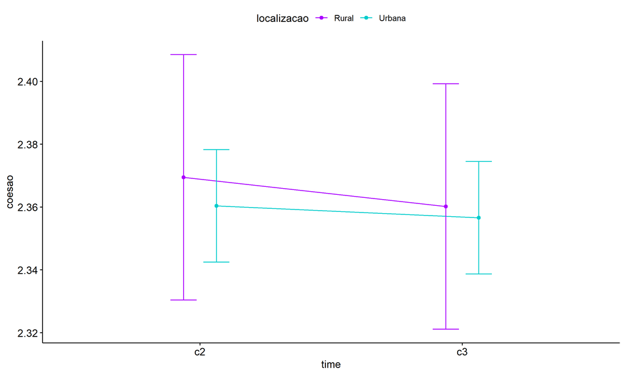

```r
pwc <- add_xy_position(pwc, x = "time", fun = "mean_se", dodge = 0.25)
pd <- position_dodge(width = 0.25)
ggline(emms, x = "time", y = "emmean", color = "localizacao",
       palette = c("#AA00FF","#00CCCC"),
       position = pd, ylab = "coesao") +
  geom_errorbar(aes(ymin = conf.low, ymax = conf.high, color = localizacao),
                position = pd, width = 0.2) +
  stat_pvalue_manual(pwc, hide.ns = T, tip.length = F, linetype = 1)
```

```r
(pwc <- ldat %>% group_by(localizacao) %>%
    emmeans_test(coesao ~ time, detailed = T, p.adjust.method = "bonferroni"))
```

```
## # A tibble: 2 × 15
##   localizacao term  .y.    group1 group2 null.value estimate     se    df
## * <fct>       <chr> <chr>  <chr>  <chr>       <dbl>    <dbl>  <dbl> <dbl>
## 1 Rural       time  coesao c2     c3              0  0.00927 0.0282  8080
## 2 Urbana      time  coesao c2     c3              0  0.00377 0.0129  8080
## # ℹ 6 more variables: conf.low <dbl>, conf.high <dbl>, statistic <dbl>,
## #   p <dbl>, p.adj <dbl>, p.adj.signif <chr>
```

| localizacao | term | .y. | group1 | group2 | null.value | estimate | se | df | conf.low | conf.high | statistic | p | p.adj | p.adj.signif |
| --- | --- | --- | --- | --- | --- | --- | --- | --- | --- | --- | --- | --- | --- | --- |
| Rural | time | coesao | c2 | c3 | 0 | 0.009 | 0.028 | 8080 | -0.046 | 0.065 | 0.329 | 0.742 | 0.742 | ns |
| Urbana | time | coesao | c2 | c3 | 0 | 0.004 | 0.013 | 8080 | -0.022 | 0.029 | 0.292 | 0.770 | 0.770 | ns |

```r
(emms <- get_emmeans(pwc))
```

```
## # A tibble: 4 × 8
##   localizacao time  emmean      se    df conf.low conf.high method
##   <fct>       <fct>  <dbl>   <dbl> <dbl>    <dbl>     <dbl> <chr>
## 1 Rural       c2      2.37 0.0199   8080     2.33      2.41 Emmeans test
## 2 Rural       c3      2.36 0.0199   8080     2.32      2.40 Emmeans test
## 3 Urbana      c2      2.36 0.00913  8080     2.34      2.38 Emmeans test
## 4 Urbana      c3      2.36 0.00913  8080     2.34      2.37 Emmeans test
```

| localizacao | time | emmean | se | df | conf.low | conf.high | method |
| --- | --- | --- | --- | --- | --- | --- | --- |
| Rural | c2 | 2.369 | 0.020 | 8080 | 2.330 | 2.409 | Emmeans test |
| Rural | c3 | 2.360 | 0.020 | 8080 | 2.321 | 2.399 | Emmeans test |
| Urbana | c2 | 2.360 | 0.009 | 8080 | 2.342 | 2.378 | Emmeans test |
| Urbana | c3 | 2.357 | 0.009 | 8080 | 2.339 | 2.374 | Emmeans test |

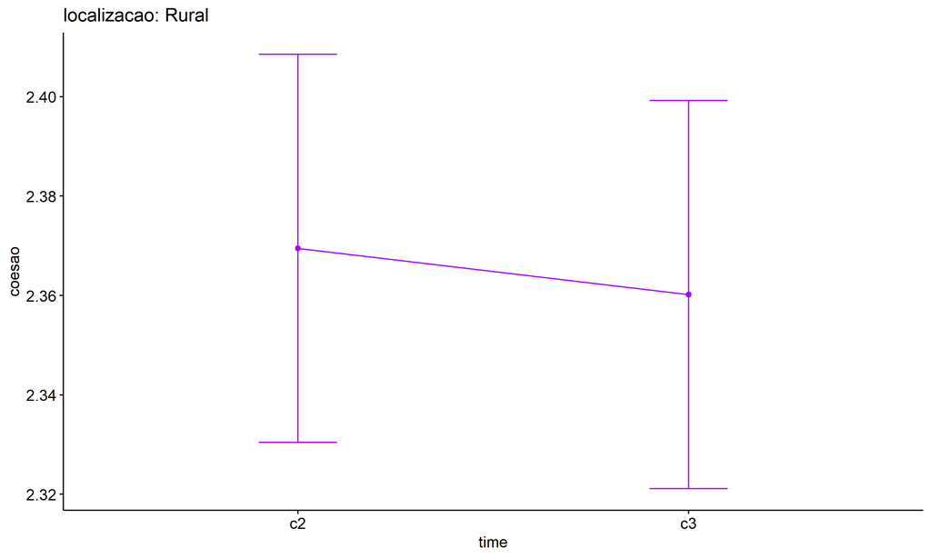

```r
emms.gg <- emms[which(emms$localizacao == "Rural"),]
if (nrow(emms.gg) > 0)
  ggline(emms.gg, x = "time", y = "emmean", color = "#AA00FF", ylab = "coesao") +
    geom_errorbar(aes(ymin = conf.low, ymax = conf.high),
                  width = 0.2, color = "#AA00FF") +
    stat_pvalue_manual(
      add_xy_position(pwc[which(pwc$localizacao == "Rural"),],
                      x = "time", fun = "mean_se"),
      hide.ns = T, color = "#AA00FF", tip.length = F) +
    labs(title = "localizacao: Rural")+
    theme(legend.text = element_blank())
```

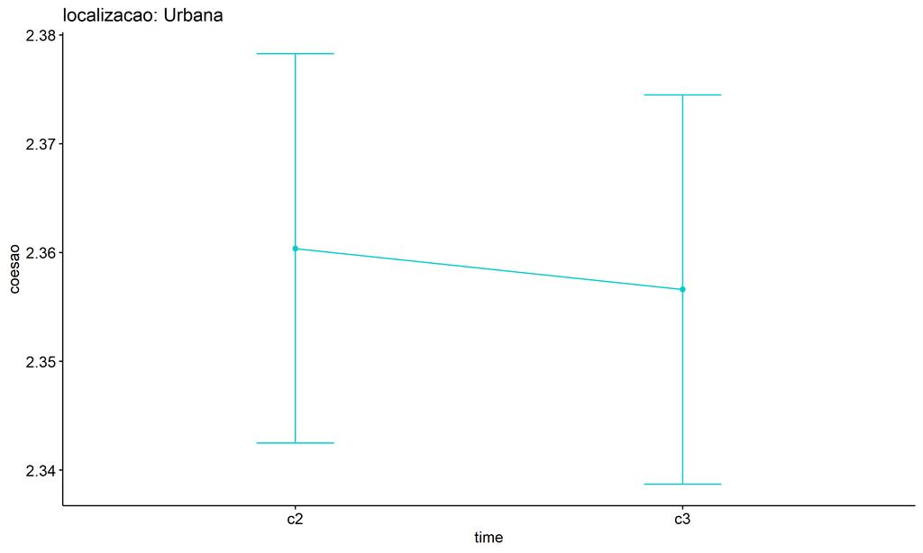

```r
emms.gg <- emms[which(emms$localizacao == "Urbana"),]
if (nrow(emms.gg) > 0)
  ggline(emms.gg, x = "time", y = "emmean", color = "#00CCCC", ylab = "coesao") +
    geom_errorbar(aes(ymin = conf.low, ymax = conf.high),
                  width = 0.2, color = "#00CCCC") +
    stat_pvalue_manual(
      add_xy_position(pwc[which(pwc$localizacao == "Urbana"),],
                      x = "time", fun = "mean_se"),
      hide.ns = T, color = "#00CCCC", tip.length = F) +
    labs(title = "localizacao: Urbana")+
    theme(legend.text = element_blank())
```

## PairWise Computation after removing non.normal data

```r
if (length(non.ids) > 0)
  (pwc2 <- ldat2 %>% group_by(time) %>%
     emmeans_test(coesao ~ localizacao, detailed = T, p.adjust.method = "bonferroni"))
```

```r
if (length(non.ids) > 0)
  (emms2 <- get_emmeans(pwc2))
```

```r
if (length(non.ids) > 0) {
  pwc2 <- add_xy_position(pwc2, x = "time", fun = "mean_se", dodge = 0.25)
  pd2 <- position_dodge(width = 0.25)

  ggline(emms2, x = "time", y = "emmean", color = "localizacao",
         palette = c("#AA00FF","#00CCCC"),
         position = pd, ylab = "coesao") +
    geom_errorbar(aes(ymin = conf.low, ymax = conf.high, color = localizacao),
                position = pd, width = 0.2) +
    stat_pvalue_manual(pwc2, hide.ns = T, tip.length = F, linetype = 1)
}
```

```r
if (length(non.ids) > 0)
  (pwc2 <- ldat2 %>% group_by(localizacao) %>%
     emmeans_test(coesao ~ time, detailed = T, p.adjust.method = "bonferroni"))
```

```r
if (length(non.ids) > 0)
  (emms2 <- get_emmeans(pwc2))
```

```r
if (length(non.ids) > 0) {
  emms.gg <- emms2[which(emms2$localizacao == "Rural"),]
  if (nrow(emms.gg) > 0)
    ggline(emms.gg, x = "time", y = "emmean", color = "#AA00FF", ylab = "coesao") +
    geom_errorbar(aes(ymin = conf.low, ymax = conf.high),
                  width = 0.2, color = "#AA00FF") +
    stat_pvalue_manual(
      add_xy_position(pwc[which(pwc$localizacao == "Rural"),],
                      x = "time", fun = "mean_se"),
      hide.ns = T, color = "#AA00FF", tip.length = F) +
    labs(title = "localizacao: Rural") +
    theme(legend.text = element_blank())
}
```

```r
if (length(non.ids) > 0) {
  emms.gg <- emms2[which(emms2$localizacao == "Urbana"),]
  if (nrow(emms.gg) > 0)
    ggline(emms.gg, x = "time", y = "emmean", color = "#00CCCC", ylab = "coesao") +
    geom_errorbar(aes(ymin = conf.low, ymax = conf.high),
                  width = 0.2, color = "#00CCCC") +
    stat_pvalue_manual(
      add_xy_position(pwc[which(pwc$localizacao == "Urbana"),],
                      x = "time", fun = "mean_se"),
      hide.ns = T, color = "#00CCCC", tip.length = F) +
    labs(title = "localizacao: Urbana") +
    theme(legend.text = element_blank())
}
```

# ANOVA: coesao ~ time*regiao + Error(id/time)

## Data Preparation

```r
data <- edat[,c("aluno_id","regiao","ciclo","coesao")]
data <- data[data$ciclo %in% c("Segundo Ciclo","Terceiro Ciclo"),]
data$ciclo <- factor(data$ciclo, c("Segundo Ciclo","Terceiro Ciclo"))
data <- unique(data)

wdat <- spread(data, ciclo, coesao)
wdat <- wdat[complete.cases(wdat),]
colnames(wdat) <- c("id","regiao","c2","c3")

ldat <- gather(wdat, key = time, value = coesao, c2,c3) %>%
  convert_as_factor(id, time)
ldat <- remove_group_data(ldat, "coesao", c("time", "regiao"), n.limit = 30)
ldat$regiao <- factor(ldat$regiao, sort(unique(ldat$regiao)))
```

### Check assumptions: Identifying Outliers

```r
outliers <- identify_outliers(group_by(ldat, time, regiao), coesao)
(outliers <- outliers[outliers$is.extreme == T,])
```

```
## # A tibble: 0 × 6
## # ℹ 6 variables: regiao <fct>, time <fct>, id <fct>, coesao <dbl>,
## #   is.outlier <lgl>, is.extreme <lgl>
```

| regiao | time | id | coesao | is.outlier | is.extreme |
| --- | --- | --- | --- | --- | --- |

### Check assumptions: Normality Test

```r
(normality.df <- normality.test.per.groups(ldat, "coesao", c("time", "regiao")))
```

```
##       var variable time       regiao    n    skewness   kurtosis symmetry
## 1  coesao   coesao   c2 Centro-Oeste  198  0.12684646 -0.7661074      YES
## 2  coesao   coesao   c2     Nordeste 1464 -0.17077298 -0.3863569      YES
## 3  coesao   coesao   c2        Norte  435 -0.25301749 -0.3533233      YES
## 4  coesao   coesao   c2      Sudeste 1473 -0.12498333 -0.1047346      YES
## 5  coesao   coesao   c2          Sul  472 -0.23967033 -0.0294736      YES
## 6  coesao   coesao   c3 Centro-Oeste  198 -0.07337694  0.1997756      YES
## 7  coesao   coesao   c3     Nordeste 1464 -0.09307087 -0.6612780      YES
## 8  coesao   coesao   c3        Norte  435 -0.26594160 -0.3666328      YES
## 9  coesao   coesao   c3      Sudeste 1473 -0.31728009 -0.3762164      YES
## 10 coesao   coesao   c3          Sul  472 -0.28321407 -0.3947666      YES
##     statistic     method            p p.signif normality
## 1  11.0657226 D'Agostino 3.954657e-03        *        QQ
## 2  20.3921793 D'Agostino 3.731595e-05      ***         -
## 3   7.2876796 D'Agostino 2.615173e-02       ns         -
## 4   4.4032137 D'Agostino 1.106253e-01       ns         -
## 5   4.5715129 D'Agostino 1.016971e-01       ns         -
## 6   0.9566728 D'Agostino 6.198137e-01       ns        QQ
## 7  63.5116697 D'Agostino 1.620926e-14     ****         -
## 8   8.0446338 D'Agostino 1.791142e-02       ns         -
## 9  36.3491414 D'Agostino 1.279040e-08     ****         -
## 10 10.2232838 D'Agostino 6.026181e-03        *         -
```

| var | variable | time | regiao | n | skewness | kurtosis | symmetry | statistic | method | p | p.signif | normality |
| --- | --- | --- | --- | --- | --- | --- | --- | --- | --- | --- | --- | --- |
| coesao | coesao | c2 | Centro-Oeste | 198 | 0.127 | -0.766 | YES | 11.066 | D’Agostino | 0.004 | * | QQ |
| coesao | coesao | c2 | Nordeste | 1464 | -0.171 | -0.386 | YES | 20.392 | D’Agostino | 0.000 | *** | - |
| coesao | coesao | c2 | Norte | 435 | -0.253 | -0.353 | YES | 7.288 | D’Agostino | 0.026 | ns | - |
| coesao | coesao | c2 | Sudeste | 1473 | -0.125 | -0.105 | YES | 4.403 | D’Agostino | 0.111 | ns | - |
| coesao | coesao | c2 | Sul | 472 | -0.240 | -0.029 | YES | 4.572 | D’Agostino | 0.102 | ns | - |
| coesao | coesao | c3 | Centro-Oeste | 198 | -0.073 | 0.200 | YES | 0.957 | D’Agostino | 0.620 | ns | QQ |
| coesao | coesao | c3 | Nordeste | 1464 | -0.093 | -0.661 | YES | 63.512 | D’Agostino | 0.000 | **** | - |
| coesao | coesao | c3 | Norte | 435 | -0.266 | -0.367 | YES | 8.045 | D’Agostino | 0.018 | ns | - |
| coesao | coesao | c3 | Sudeste | 1473 | -0.317 | -0.376 | YES | 36.349 | D’Agostino | 0.000 | **** | - |
| coesao | coesao | c3 | Sul | 472 | -0.283 | -0.395 | YES | 10.223 | D’Agostino | 0.006 | * | - |

```r
(non.ids <- unique(do.call(
  c, lapply(which(normality.df$normality == 'NO'), FUN = function(i) {
  idx = which(ldat$time == normality.df$time[i] &
                ldat$regiao == normality.df$regiao[i])
  getNonNormal(ldat$"coesao"[idx], ldat$id[idx])
}))))
```

```r
if (length(non.ids) > 0)
  ldat2 <- ldat[!ldat$id %in% non.ids,]
```

### Summary Statistics

```r
(sdat <- ldat %>% group_by(time, regiao) %>%
   get_summary_stats(coesao, type = "mean_sd"))
```

```
## # A tibble: 10 × 6
##    regiao       time  variable     n  mean    sd
##    <fct>        <fct> <fct>    <dbl> <dbl> <dbl>
##  1 Centro-Oeste c2    coesao     198  2.33 0.482
##  2 Nordeste     c2    coesao    1464  2.37 0.528
##  3 Norte        c2    coesao     435  2.36 0.527
##  4 Sudeste      c2    coesao    1473  2.36 0.467
##  5 Sul          c2    coesao     472  2.38 0.56
##  6 Centro-Oeste c3    coesao     198  2.30 0.53
##  7 Nordeste     c3    coesao    1464  2.38 0.534
##  8 Norte        c3    coesao     435  2.31 0.552
##  9 Sudeste      c3    coesao    1473  2.36 0.538
## 10 Sul          c3    coesao     472  2.37 0.604
```

| regiao | time | variable | n | mean | sd |
| --- | --- | --- | --- | --- | --- |
| Centro-Oeste | c2 | coesao | 198 | 2.331 | 0.482 |
| Nordeste | c2 | coesao | 1464 | 2.365 | 0.528 |
| Norte | c2 | coesao | 435 | 2.358 | 0.527 |
| Sudeste | c2 | coesao | 1473 | 2.359 | 0.467 |
| Sul | c2 | coesao | 472 | 2.377 | 0.560 |
| Centro-Oeste | c3 | coesao | 198 | 2.301 | 0.530 |
| Nordeste | c3 | coesao | 1464 | 2.378 | 0.534 |
| Norte | c3 | coesao | 435 | 2.311 | 0.552 |
| Sudeste | c3 | coesao | 1473 | 2.355 | 0.538 |
| Sul | c3 | coesao | 472 | 2.365 | 0.604 |

```r
if (length(non.ids) > 0)
  (sdat <- ldat2 %>% group_by(time, regiao) %>%
      get_summary_stats(coesao, type = "mean_sd"))
```

| regiao | time | variable | n | mean | sd |
| --- | --- | --- | --- | --- | --- |
| Centro-Oeste | c2 | coesao | 198 | 2.331 | 0.482 |
| Nordeste | c2 | coesao | 1464 | 2.365 | 0.528 |
| Norte | c2 | coesao | 435 | 2.358 | 0.527 |
| Sudeste | c2 | coesao | 1473 | 2.359 | 0.467 |
| Sul | c2 | coesao | 472 | 2.377 | 0.560 |
| Centro-Oeste | c3 | coesao | 198 | 2.301 | 0.530 |
| Nordeste | c3 | coesao | 1464 | 2.378 | 0.534 |
| Norte | c3 | coesao | 435 | 2.311 | 0.552 |
| Sudeste | c3 | coesao | 1473 | 2.355 | 0.538 |
| Sul | c3 | coesao | 472 | 2.365 | 0.604 |

## ANOVA Computation

```r
(res.aov <- anova_test(ldat, dv = coesao, wid = id, between = regiao, within = time))
```

```
## ANOVA Table (type III tests)
##
##        Effect DFn  DFd     F     p p<.05      ges
## 1      regiao   4 4037 1.501 0.199       0.000826
## 2        time   1 4037 1.190 0.275       0.000131
## 3 regiao:time   4 4037 0.674 0.610       0.000297
```

## ANOVA Computation after removing non.normal data

```r
if (length(non.ids) > 0)
  (res.aov2 <- anova_test(ldat2, dv = coesao, wid = id, between = regiao , within = time))
```

## PairWise Computation

```r
(pwc <- ldat %>% group_by(time) %>%
   emmeans_test(coesao ~ regiao, detailed = T, p.adjust.method = "bonferroni"))
```

| time | term | .y. | group1 | group2 | null.value | estimate | se | df | conf.low | conf.high | statistic | p | p.adj | p.adj.signif |
| --- | --- | --- | --- | --- | --- | --- | --- | --- | --- | --- | --- | --- | --- | --- |
| c2 | regiao | coesao | Centro | Oeste | 0 | -0.034 | 0.040 | 8074 | -0.112 | 0.044 | -0.855 | 0.392 | 1.000 | ns |
| c2 | regiao | coesao | Centro | Oeste | 0 | -0.027 | 0.045 | 8074 | -0.115 | 0.062 | -0.589 | 0.556 | 1.000 | ns |
| c2 | regiao | coesao | Centro | Oeste | 0 | -0.028 | 0.040 | 8074 | -0.106 | 0.050 | -0.699 | 0.485 | 1.000 | ns |
| c2 | regiao | coesao | Centro | Oeste | 0 | -0.046 | 0.045 | 8074 | -0.133 | 0.042 | -1.020 | 0.308 | 1.000 | ns |
| c2 | regiao | coesao | Nordeste | Norte | 0 | 0.008 | 0.029 | 8074 | -0.049 | 0.064 | 0.261 | 0.794 | 1.000 | ns |
| c2 | regiao | coesao | Nordeste | Sudeste | 0 | 0.006 | 0.019 | 8074 | -0.032 | 0.044 | 0.321 | 0.748 | 1.000 | ns |
| c2 | regiao | coesao | Nordeste | Sul | 0 | -0.011 | 0.028 | 8074 | -0.066 | 0.043 | -0.408 | 0.683 | 1.000 | ns |
| c2 | regiao | coesao | Norte | Sudeste | 0 | -0.001 | 0.029 | 8074 | -0.058 | 0.055 | -0.044 | 0.965 | 1.000 | ns |
| c2 | regiao | coesao | Norte | Sul | 0 | -0.019 | 0.035 | 8074 | -0.088 | 0.050 | -0.539 | 0.590 | 1.000 | ns |
| c2 | regiao | coesao | Sudeste | Sul | 0 | -0.018 | 0.028 | 8074 | -0.072 | 0.037 | -0.632 | 0.527 | 1.000 | ns |
| c3 | regiao | coesao | Centro | Oeste | 0 | -0.077 | 0.040 | 8074 | -0.155 | 0.001 | -1.932 | 0.053 | 0.533 | ns |
| c3 | regiao | coesao | Centro | Oeste | 0 | -0.011 | 0.045 | 8074 | -0.100 | 0.078 | -0.243 | 0.808 | 1.000 | ns |
| c3 | regiao | coesao | Centro | Oeste | 0 | -0.055 | 0.040 | 8074 | -0.133 | 0.023 | -1.375 | 0.169 | 1.000 | ns |
| c3 | regiao | coesao | Centro | Oeste | 0 | -0.065 | 0.045 | 8074 | -0.152 | 0.023 | -1.455 | 0.146 | 1.000 | ns |
| c3 | regiao | coesao | Nordeste | Norte | 0 | 0.066 | 0.029 | 8074 | 0.010 | 0.123 | 2.298 | 0.022 | 0.216 | ns |
| c3 | regiao | coesao | Nordeste | Sudeste | 0 | 0.022 | 0.019 | 8074 | -0.016 | 0.060 | 1.145 | 0.252 | 1.000 | ns |
| c3 | regiao | coesao | Nordeste | Sul | 0 | 0.012 | 0.028 | 8074 | -0.043 | 0.067 | 0.437 | 0.662 | 1.000 | ns |
| c3 | regiao | coesao | Norte | Sudeste | 0 | -0.044 | 0.029 | 8074 | -0.100 | 0.013 | -1.525 | 0.127 | 1.000 | ns |
| c3 | regiao | coesao | Norte | Sul | 0 | -0.054 | 0.035 | 8074 | -0.123 | 0.015 | -1.540 | 0.124 | 1.000 | ns |
| c3 | regiao | coesao | Sudeste | Sul | 0 | -0.010 | 0.028 | 8074 | -0.065 | 0.045 | -0.361 | 0.718 | 1.000 | ns |

```r
(emms <- get_emmeans(pwc))
```

```
## # A tibble: 10 × 8
##    time  regiao       emmean     se    df conf.low conf.high method
##    <fct> <fct>         <dbl>  <dbl> <dbl>    <dbl>     <dbl> <chr>
##  1 c2    Centro-Oeste   2.33 0.0375  8074     2.26      2.40 Emmeans test
##  2 c2    Nordeste       2.37 0.0138  8074     2.34      2.39 Emmeans test
##  3 c2    Norte          2.36 0.0253  8074     2.31      2.41 Emmeans test
##  4 c2    Sudeste        2.36 0.0137  8074     2.33      2.39 Emmeans test
##  5 c2    Sul            2.38 0.0243  8074     2.33      2.42 Emmeans test
##  6 c3    Centro-Oeste   2.30 0.0375  8074     2.23      2.37 Emmeans test
##  7 c3    Nordeste       2.38 0.0138  8074     2.35      2.40 Emmeans test
##  8 c3    Norte          2.31 0.0253  8074     2.26      2.36 Emmeans test
##  9 c3    Sudeste        2.36 0.0137  8074     2.33      2.38 Emmeans test
## 10 c3    Sul            2.37 0.0243  8074     2.32      2.41 Emmeans test
```

| time | regiao | emmean | se | df | conf.low | conf.high | method |
| --- | --- | --- | --- | --- | --- | --- | --- |
| c2 | Centro-Oeste | 2.331 | 0.037 | 8074 | 2.258 | 2.405 | Emmeans test |
| c2 | Nordeste | 2.365 | 0.014 | 8074 | 2.338 | 2.392 | Emmeans test |
| c2 | Norte | 2.358 | 0.025 | 8074 | 2.308 | 2.407 | Emmeans test |
| c2 | Sudeste | 2.359 | 0.014 | 8074 | 2.332 | 2.386 | Emmeans test |
| c2 | Sul | 2.377 | 0.024 | 8074 | 2.329 | 2.424 | Emmeans test |
| c3 | Centro-Oeste | 2.301 | 0.037 | 8074 | 2.227 | 2.374 | Emmeans test |
| c3 | Nordeste | 2.378 | 0.014 | 8074 | 2.351 | 2.405 | Emmeans test |
| c3 | Norte | 2.311 | 0.025 | 8074 | 2.262 | 2.361 | Emmeans test |
| c3 | Sudeste | 2.355 | 0.014 | 8074 | 2.328 | 2.382 | Emmeans test |
| c3 | Sul | 2.365 | 0.024 | 8074 | 2.318 | 2.413 | Emmeans test |

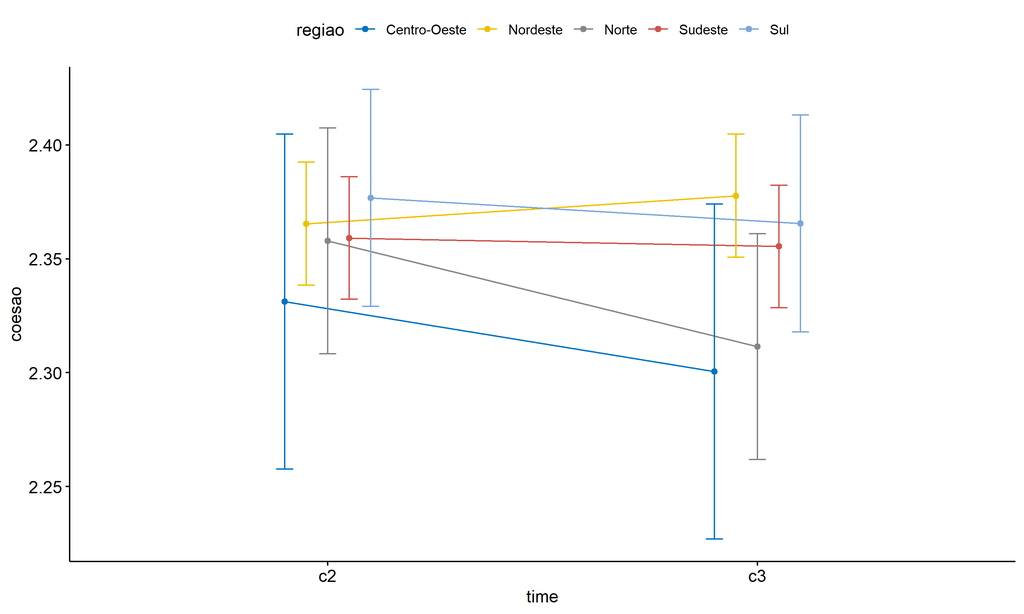

```r
pwc <- add_xy_position(pwc, x = "time", fun = "mean_se", dodge = 0.25)
pd <- position_dodge(width = 0.25)
ggline(emms, x = "time", y = "emmean", color = "regiao",
       palette = c("#0073C2FF","#EFC000FF","#868686FF","#CD534CFF","#7AA6DCFF"),
       position = pd, ylab = "coesao") +
  geom_errorbar(aes(ymin = conf.low, ymax = conf.high, color = regiao),
                position = pd, width = 0.2) +
  stat_pvalue_manual(pwc, hide.ns = T, tip.length = F, linetype = 1)
```

```r
(pwc <- ldat %>% group_by(regiao) %>%
    emmeans_test(coesao ~ time, detailed = T, p.adjust.method = "bonferroni"))
```

```
## # A tibble: 5 × 15
##   regiao     term  .y.   group1 group2 null.value estimate     se    df conf.low
## * <fct>      <chr> <chr> <chr>  <chr>       <dbl>    <dbl>  <dbl> <dbl>    <dbl>
## 1 Centro-Oe… time  coes… c2     c3              0  0.0307  0.0530  8074  -0.0732
## 2 Nordeste   time  coes… c2     c3              0 -0.0123  0.0195  8074  -0.0505
## 3 Norte      time  coes… c2     c3              0  0.0464  0.0358  8074  -0.0237
## 4 Sudeste    time  coes… c2     c3              0  0.00373 0.0194  8074  -0.0344
## 5 Sul        time  coes… c2     c3              0  0.0113  0.0343  8074  -0.0560
## # ℹ 5 more variables: conf.high <dbl>, statistic <dbl>, p <dbl>, p.adj <dbl>,
## #   p.adj.signif <chr>
```

| regiao | term | .y. | group1 | group2 | null.value | estimate | se | df | conf.low | conf.high | statistic | p | p.adj | p.adj.signif |
| --- | --- | --- | --- | --- | --- | --- | --- | --- | --- | --- | --- | --- | --- | --- |
| Centro-Oeste | time | coesao | c2 | c3 | 0 | 0.031 | 0.053 | 8074 | -0.073 | 0.135 | 0.580 | 0.562 | 0.562 | ns |
| Nordeste | time | coesao | c2 | c3 | 0 | -0.012 | 0.019 | 8074 | -0.051 | 0.026 | -0.631 | 0.528 | 0.528 | ns |
| Norte | time | coesao | c2 | c3 | 0 | 0.046 | 0.036 | 8074 | -0.024 | 0.116 | 1.296 | 0.195 | 0.195 | ns |
| Sudeste | time | coesao | c2 | c3 | 0 | 0.004 | 0.019 | 8074 | -0.034 | 0.042 | 0.192 | 0.848 | 0.848 | ns |
| Sul | time | coesao | c2 | c3 | 0 | 0.011 | 0.034 | 8074 | -0.056 | 0.079 | 0.329 | 0.742 | 0.742 | ns |

```r
(emms <- get_emmeans(pwc))
```

```
## # A tibble: 10 × 8
##    regiao       time  emmean     se    df conf.low conf.high method
##    <fct>        <fct>  <dbl>  <dbl> <dbl>    <dbl>     <dbl> <chr>
##  1 Centro-Oeste c2      2.33 0.0375  8074     2.26      2.40 Emmeans test
##  2 Centro-Oeste c3      2.30 0.0375  8074     2.23      2.37 Emmeans test
##  3 Nordeste     c2      2.37 0.0138  8074     2.34      2.39 Emmeans test
##  4 Nordeste     c3      2.38 0.0138  8074     2.35      2.40 Emmeans test
##  5 Norte        c2      2.36 0.0253  8074     2.31      2.41 Emmeans test
##  6 Norte        c3      2.31 0.0253  8074     2.26      2.36 Emmeans test
##  7 Sudeste      c2      2.36 0.0137  8074     2.33      2.39 Emmeans test
##  8 Sudeste      c3      2.36 0.0137  8074     2.33      2.38 Emmeans test
##  9 Sul          c2      2.38 0.0243  8074     2.33      2.42 Emmeans test
## 10 Sul          c3      2.37 0.0243  8074     2.32      2.41 Emmeans test
```

| regiao | time | emmean | se | df | conf.low | conf.high | method |
| --- | --- | --- | --- | --- | --- | --- | --- |
| Centro-Oeste | c2 | 2.331 | 0.037 | 8074 | 2.258 | 2.405 | Emmeans test |
| Centro-Oeste | c3 | 2.301 | 0.037 | 8074 | 2.227 | 2.374 | Emmeans test |
| Nordeste | c2 | 2.365 | 0.014 | 8074 | 2.338 | 2.392 | Emmeans test |
| Nordeste | c3 | 2.378 | 0.014 | 8074 | 2.351 | 2.405 | Emmeans test |
| Norte | c2 | 2.358 | 0.025 | 8074 | 2.308 | 2.407 | Emmeans test |
| Norte | c3 | 2.311 | 0.025 | 8074 | 2.262 | 2.361 | Emmeans test |
| Sudeste | c2 | 2.359 | 0.014 | 8074 | 2.332 | 2.386 | Emmeans test |
| Sudeste | c3 | 2.355 | 0.014 | 8074 | 2.328 | 2.382 | Emmeans test |
| Sul | c2 | 2.377 | 0.024 | 8074 | 2.329 | 2.424 | Emmeans test |
| Sul | c3 | 2.365 | 0.024 | 8074 | 2.318 | 2.413 | Emmeans test |

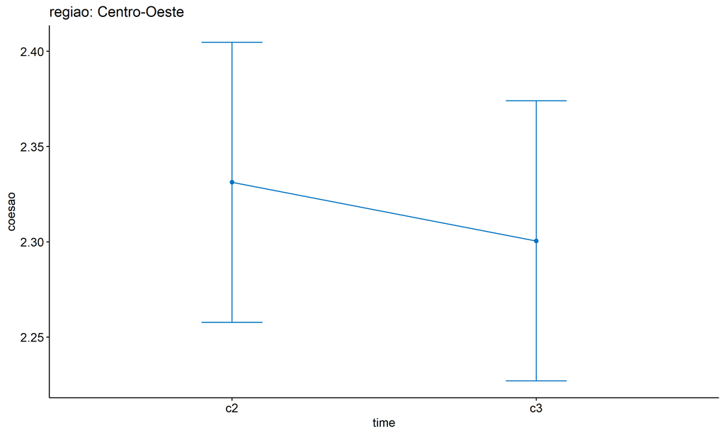

```r
emms.gg <- emms[which(emms$regiao == "Centro-Oeste"),]
if (nrow(emms.gg) > 0)
  ggline(emms.gg, x = "time", y = "emmean", color = "#0073C2FF", ylab = "coesao") +
    geom_errorbar(aes(ymin = conf.low, ymax = conf.high),
                  width = 0.2, color = "#0073C2FF") +
    stat_pvalue_manual(
      add_xy_position(pwc[which(pwc$regiao == "Centro-Oeste"),],
                      x = "time", fun = "mean_se"),
      hide.ns = T, color = "#0073C2FF", tip.length = F) +
    labs(title = "regiao: Centro-Oeste")+
    theme(legend.text = element_blank())
```

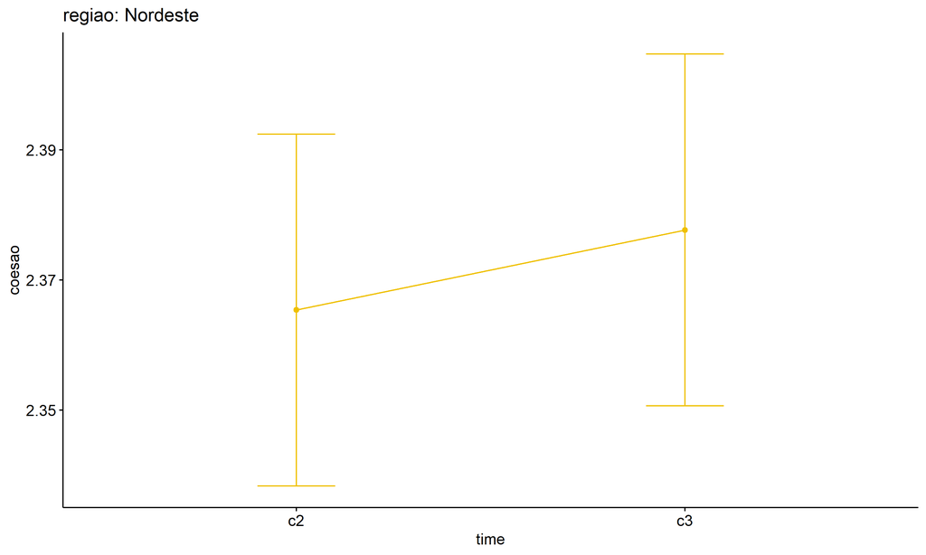

```r
emms.gg <- emms[which(emms$regiao == "Nordeste"),]
if (nrow(emms.gg) > 0)
  ggline(emms.gg, x = "time", y = "emmean", color = "#EFC000FF", ylab = "coesao") +
    geom_errorbar(aes(ymin = conf.low, ymax = conf.high),
                  width = 0.2, color = "#EFC000FF") +
    stat_pvalue_manual(
      add_xy_position(pwc[which(pwc$regiao == "Nordeste"),],
                      x = "time", fun = "mean_se"),
      hide.ns = T, color = "#EFC000FF", tip.length = F) +
    labs(title = "regiao: Nordeste")+
    theme(legend.text = element_blank())
```

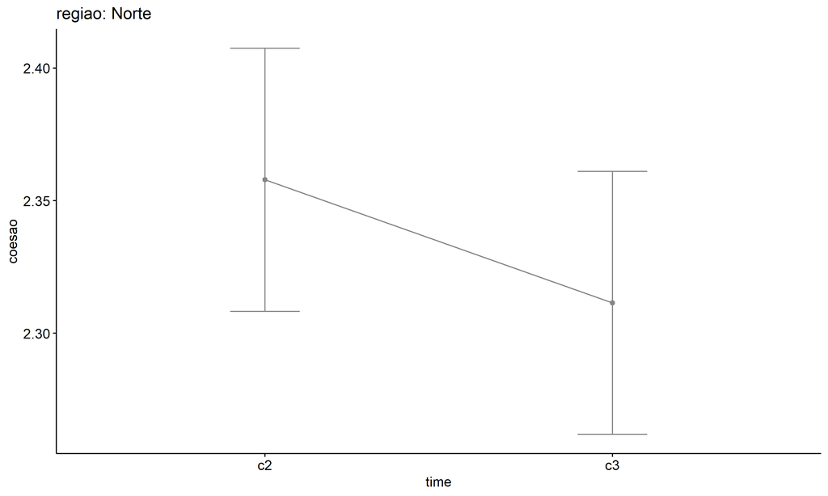

```r
emms.gg <- emms[which(emms$regiao == "Norte"),]
if (nrow(emms.gg) > 0)
  ggline(emms.gg, x = "time", y = "emmean", color = "#868686FF", ylab = "coesao") +
    geom_errorbar(aes(ymin = conf.low, ymax = conf.high),
                  width = 0.2, color = "#868686FF") +
    stat_pvalue_manual(
      add_xy_position(pwc[which(pwc$regiao == "Norte"),],
                      x = "time", fun = "mean_se"),
      hide.ns = T, color = "#868686FF", tip.length = F) +
    labs(title = "regiao: Norte")+
    theme(legend.text = element_blank())
```

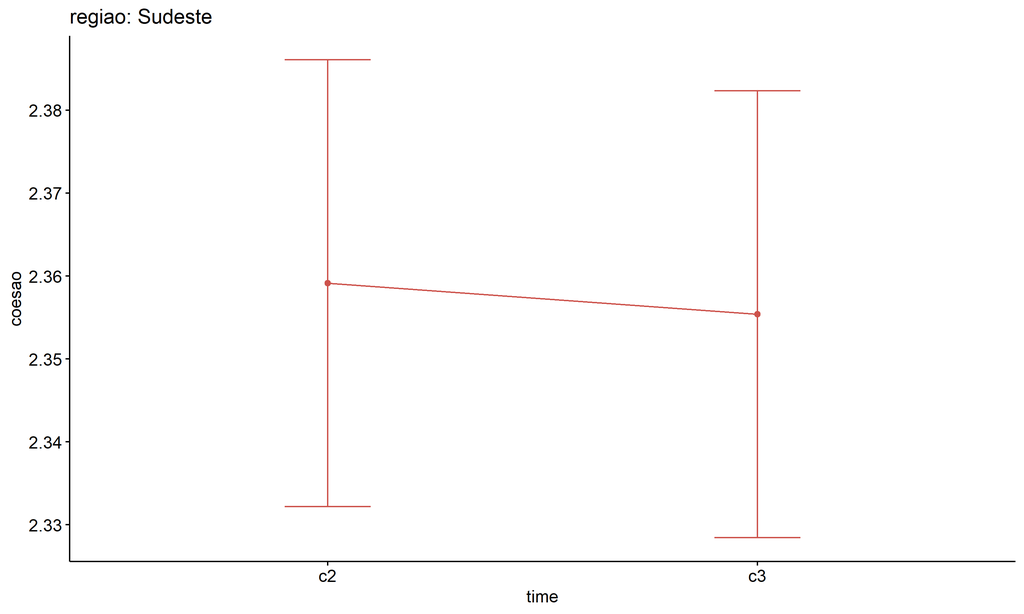

```r
emms.gg <- emms[which(emms$regiao == "Sudeste"),]
if (nrow(emms.gg) > 0)
  ggline(emms.gg, x = "time", y = "emmean", color = "#CD534CFF", ylab = "coesao") +
    geom_errorbar(aes(ymin = conf.low, ymax = conf.high),
                  width = 0.2, color = "#CD534CFF") +
    stat_pvalue_manual(
      add_xy_position(pwc[which(pwc$regiao == "Sudeste"),],
                      x = "time", fun = "mean_se"),
      hide.ns = T, color = "#CD534CFF", tip.length = F) +
    labs(title = "regiao: Sudeste")+
    theme(legend.text = element_blank())
```

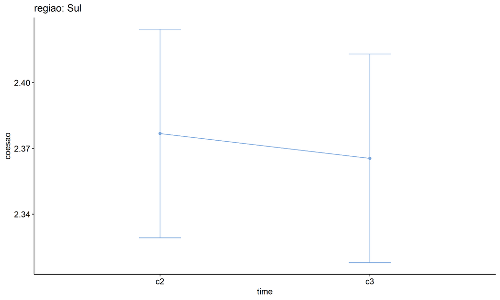

```r
emms.gg <- emms[which(emms$regiao == "Sul"),]
if (nrow(emms.gg) > 0)
  ggline(emms.gg, x = "time", y = "emmean", color = "#7AA6DCFF", ylab = "coesao") +
    geom_errorbar(aes(ymin = conf.low, ymax = conf.high),
                  width = 0.2, color = "#7AA6DCFF") +
    stat_pvalue_manual(
      add_xy_position(pwc[which(pwc$regiao == "Sul"),],
                      x = "time", fun = "mean_se"),
      hide.ns = T, color = "#7AA6DCFF", tip.length = F) +
    labs(title = "regiao: Sul")+
    theme(legend.text = element_blank())
```

## PairWise Computation after removing non.normal data

```r
if (length(non.ids) > 0)
  (pwc2 <- ldat2 %>% group_by(time) %>%
     emmeans_test(coesao ~ regiao, detailed = T, p.adjust.method = "bonferroni"))
```

```r
if (length(non.ids) > 0)
  (emms2 <- get_emmeans(pwc2))
```

```r
if (length(non.ids) > 0) {
  pwc2 <- add_xy_position(pwc2, x = "time", fun = "mean_se", dodge = 0.25)
  pd2 <- position_dodge(width = 0.25)

  ggline(emms2, x = "time", y = "emmean", color = "regiao",
         palette = c("#0073C2FF","#EFC000FF","#868686FF","#CD534CFF","#7AA6DCFF"),
         position = pd, ylab = "coesao") +
    geom_errorbar(aes(ymin = conf.low, ymax = conf.high, color = regiao),
                position = pd, width = 0.2) +
    stat_pvalue_manual(pwc2, hide.ns = T, tip.length = F, linetype = 1)
}
```

```r
if (length(non.ids) > 0)
  (pwc2 <- ldat2 %>% group_by(regiao) %>%
     emmeans_test(coesao ~ time, detailed = T, p.adjust.method = "bonferroni"))
```

```r
if (length(non.ids) > 0)
  (emms2 <- get_emmeans(pwc2))
```

```r
if (length(non.ids) > 0) {
  emms.gg <- emms2[which(emms2$regiao == "Centro-Oeste"),]
  if (nrow(emms.gg) > 0)
    ggline(emms.gg, x = "time", y = "emmean", color = "#0073C2FF", ylab = "coesao") +
    geom_errorbar(aes(ymin = conf.low, ymax = conf.high),
                  width = 0.2, color = "#0073C2FF") +
    stat_pvalue_manual(
      add_xy_position(pwc[which(pwc$regiao == "Centro-Oeste"),],
                      x = "time", fun = "mean_se"),
      hide.ns = T, color = "#0073C2FF", tip.length = F) +
    labs(title = "regiao: Centro-Oeste") +
    theme(legend.text = element_blank())
}
```

```r
if (length(non.ids) > 0) {
  emms.gg <- emms2[which(emms2$regiao == "Nordeste"),]
  if (nrow(emms.gg) > 0)
    ggline(emms.gg, x = "time", y = "emmean", color = "#EFC000FF", ylab = "coesao") +
    geom_errorbar(aes(ymin = conf.low, ymax = conf.high),
                  width = 0.2, color = "#EFC000FF") +
    stat_pvalue_manual(
      add_xy_position(pwc[which(pwc$regiao == "Nordeste"),],
                      x = "time", fun = "mean_se"),
      hide.ns = T, color = "#EFC000FF", tip.length = F) +
    labs(title = "regiao: Nordeste") +
    theme(legend.text = element_blank())
}
```

```r
if (length(non.ids) > 0) {
  emms.gg <- emms2[which(emms2$regiao == "Norte"),]
  if (nrow(emms.gg) > 0)
    ggline(emms.gg, x = "time", y = "emmean", color = "#868686FF", ylab = "coesao") +
    geom_errorbar(aes(ymin = conf.low, ymax = conf.high),
                  width = 0.2, color = "#868686FF") +
    stat_pvalue_manual(
      add_xy_position(pwc[which(pwc$regiao == "Norte"),],
                      x = "time", fun = "mean_se"),
      hide.ns = T, color = "#868686FF", tip.length = F) +
    labs(title = "regiao: Norte") +
    theme(legend.text = element_blank())
}
```

```r
if (length(non.ids) > 0) {
  emms.gg <- emms2[which(emms2$regiao == "Sudeste"),]
  if (nrow(emms.gg) > 0)
    ggline(emms.gg, x = "time", y = "emmean", color = "#CD534CFF", ylab = "coesao") +
    geom_errorbar(aes(ymin = conf.low, ymax = conf.high),
                  width = 0.2, color = "#CD534CFF") +
    stat_pvalue_manual(
      add_xy_position(pwc[which(pwc$regiao == "Sudeste"),],
                      x = "time", fun = "mean_se"),
      hide.ns = T, color = "#CD534CFF", tip.length = F) +
    labs(title = "regiao: Sudeste") +
    theme(legend.text = element_blank())
}
```

```r
if (length(non.ids) > 0) {
  emms.gg <- emms2[which(emms2$regiao == "Sul"),]
  if (nrow(emms.gg) > 0)
    ggline(emms.gg, x = "time", y = "emmean", color = "#7AA6DCFF", ylab = "coesao") +
    geom_errorbar(aes(ymin = conf.low, ymax = conf.high),
                  width = 0.2, color = "#7AA6DCFF") +
    stat_pvalue_manual(
      add_xy_position(pwc[which(pwc$regiao == "Sul"),],
                      x = "time", fun = "mean_se"),
      hide.ns = T, color = "#7AA6DCFF", tip.length = F) +
    labs(title = "regiao: Sul") +
    theme(legend.text = element_blank())
}
```

# ANOVA: coesao ~ time*porte + Error(id/time)

## Data Preparation

```r
data <- edat[,c("aluno_id","porte","ciclo","coesao")]
data <- data[data$ciclo %in% c("Segundo Ciclo","Terceiro Ciclo"),]
data$ciclo <- factor(data$ciclo, c("Segundo Ciclo","Terceiro Ciclo"))
data <- unique(data)

wdat <- spread(data, ciclo, coesao)
wdat <- wdat[complete.cases(wdat),]
colnames(wdat) <- c("id","porte","c2","c3")

ldat <- gather(wdat, key = time, value = coesao, c2,c3) %>%
  convert_as_factor(id, time)
ldat <- remove_group_data(ldat, "coesao", c("time", "porte"), n.limit = 30)
ldat$porte <- factor(ldat$porte, sort(unique(ldat$porte)))
```

### Check assumptions: Identifying Outliers

```r
outliers <- identify_outliers(group_by(ldat, time, porte), coesao)
(outliers <- outliers[outliers$is.extreme == T,])
```

```
## [1] porte      time       id         coesao     is.outlier is.extreme
## <0 rows> (or 0-length row.names)
```

| porte | time | id | coesao | is.outlier | is.extreme |
| --- | --- | --- | --- | --- | --- |

### Check assumptions: Normality Test

```r
(normality.df <- normality.test.per.groups(ldat, "coesao", c("time", "porte")))
```

```
##       var variable time                                        porte    n
## 1  coesao   coesao   c2           Até 50 matrículas de escolarização   39
## 2  coesao   coesao   c2  Entre 201 e 500 matrículas de escolarização 1488
## 3  coesao   coesao   c2 Entre 501 e 1000 matrículas de escolarização 1922
## 4  coesao   coesao   c2   Entre 51 e 200 matrículas de escolarização  502
## 5  coesao   coesao   c2     Mais de 1000 matrículas de escolarização   91
## 6  coesao   coesao   c3           Até 50 matrículas de escolarização   39
## 7  coesao   coesao   c3  Entre 201 e 500 matrículas de escolarização 1488
## 8  coesao   coesao   c3 Entre 501 e 1000 matrículas de escolarização 1922
## 9  coesao   coesao   c3   Entre 51 e 200 matrículas de escolarização  502
## 10 coesao   coesao   c3     Mais de 1000 matrículas de escolarização   91
##        skewness   kurtosis symmetry  statistic       method            p
## 1   0.000000000  0.0000000 few data         NA         <NA> 1.000000e+00
## 2  -0.185995636 -0.3344339      YES 17.8881382   D'Agostino 1.305089e-04
## 3  -0.169132063 -0.0736963      YES  9.4521578   D'Agostino 8.861149e-03
```

[output cut: 18 more lines]

| var | variable | time | porte | n | skewness | kurtosis | symmetry | statistic | method | p | p.signif | normality |
| --- | --- | --- | --- | --- | --- | --- | --- | --- | --- | --- | --- | --- |
| coesao | coesao | c2 | Até 50 matrículas de escolarização | 39 | 0.000 | 0.000 | few data | NA | NA | 1.000 | NA | NO |
| coesao | coesao | c2 | Entre 201 e 500 matrículas de escolarização | 1488 | -0.186 | -0.334 | YES | 17.888 | D’Agostino | 0.000 | ** | - |
| coesao | coesao | c2 | Entre 501 e 1000 matrículas de escolarização | 1922 | -0.169 | -0.074 | YES | 9.452 | D’Agostino | 0.009 | * | - |
| coesao | coesao | c2 | Entre 51 e 200 matrículas de escolarização | 502 | -0.168 | -0.371 | YES | 5.989 | D’Agostino | 0.050 | ns | - |
| coesao | coesao | c2 | Mais de 1000 matrículas de escolarização | 91 | 0.035 | -0.702 | YES | 2.509 | D’Agostino | 0.285 | ns | YES |
| coesao | coesao | c3 | Até 50 matrículas de escolarização | 39 | 0.055 | -0.821 | YES | 0.741 | Shapiro-Wilk | 0.000 | **** | NO |
| coesao | coesao | c3 | Entre 201 e 500 matrículas de escolarização | 1488 | -0.209 | -0.577 | YES | 51.681 | D’Agostino | 0.000 | **** | - |
| coesao | coesao | c3 | Entre 501 e 1000 matrículas de escolarização | 1922 | -0.281 | -0.340 | YES | 37.334 | D’Agostino | 0.000 | **** | - |
| coesao | coesao | c3 | Entre 51 e 200 matrículas de escolarização | 502 | -0.042 | -0.534 | YES | 10.118 | D’Agostino | 0.006 | * | - |
| coesao | coesao | c3 | Mais de 1000 matrículas de escolarização | 91 | 0.010 | -0.426 | YES | 0.350 | D’Agostino | 0.839 | ns | YES |

```r
(non.ids <- unique(do.call(
  c, lapply(which(normality.df$normality == 'NO'), FUN = function(i) {
  idx = which(ldat$time == normality.df$time[i] &
                ldat$porte == normality.df$porte[i])
  getNonNormal(ldat$"coesao"[idx], ldat$id[idx])
}))))
```

```
## [1] "ZFu1gNSlJi6WerbxgitV" "wEcu8jbom5Ui9WLqplNb" "tNXwXm3gSuhYYg0Zi6Jt"
## [4] "QBXFRi4iRN3uHcvl4ZTf" "pURonQfq0IqWOeSSc60L" "eZMpI23XTiqNuckAohvP"
## [7] "MqmsPo8CcZiXbjHViNOu"
```

```r
if (length(non.ids) > 0)
  ldat2 <- ldat[!ldat$id %in% non.ids,]
```

### Summary Statistics

```r
(sdat <- ldat %>% group_by(time, porte) %>%
   get_summary_stats(coesao, type = "mean_sd"))
```

```
## # A tibble: 10 × 6
##    porte                                        time  variable     n  mean    sd
##    <fct>                                        <fct> <fct>    <dbl> <dbl> <dbl>
##  1 Até 50 matrículas de escolarização           c2    coesao      39  2.32 0.466
##  2 Entre 201 e 500 matrículas de escolarização  c2    coesao    1488  2.37 0.514
##  3 Entre 501 e 1000 matrículas de escolarização c2    coesao    1922  2.36 0.487
##  4 Entre 51 e 200 matrículas de escolarização   c2    coesao     502  2.37 0.572
##  5 Mais de 1000 matrículas de escolarização     c2    coesao      91  2.35 0.498
##  6 Até 50 matrículas de escolarização           c3    coesao      39  2.35 0.515
##  7 Entre 201 e 500 matrículas de escolarização  c3    coesao    1488  2.38 0.535
##  8 Entre 501 e 1000 matrículas de escolarização c3    coesao    1922  2.35 0.545
##  9 Entre 51 e 200 matrículas de escolarização   c3    coesao     502  2.36 0.554
## 10 Mais de 1000 matrículas de escolarização     c3    coesao      91  2.24 0.705
```

| porte | time | variable | n | mean | sd |
| --- | --- | --- | --- | --- | --- |
| Até 50 matrículas de escolarização | c2 | coesao | 39 | 2.321 | 0.466 |
| Entre 201 e 500 matrículas de escolarização | c2 | coesao | 1488 | 2.367 | 0.514 |
| Entre 501 e 1000 matrículas de escolarização | c2 | coesao | 1922 | 2.358 | 0.487 |
| Entre 51 e 200 matrículas de escolarização | c2 | coesao | 502 | 2.367 | 0.572 |
| Mais de 1000 matrículas de escolarização | c2 | coesao | 91 | 2.346 | 0.498 |
| Até 50 matrículas de escolarização | c3 | coesao | 39 | 2.346 | 0.515 |
| Entre 201 e 500 matrículas de escolarização | c3 | coesao | 1488 | 2.375 | 0.535 |
| Entre 501 e 1000 matrículas de escolarização | c3 | coesao | 1922 | 2.350 | 0.545 |
| Entre 51 e 200 matrículas de escolarização | c3 | coesao | 502 | 2.355 | 0.554 |
| Mais de 1000 matrículas de escolarização | c3 | coesao | 91 | 2.242 | 0.705 |

```r
if (length(non.ids) > 0)
  (sdat <- ldat2 %>% group_by(time, porte) %>%
      get_summary_stats(coesao, type = "mean_sd"))
```

```
## # A tibble: 10 × 6
##    porte                                        time  variable     n  mean    sd
##    <fct>                                        <fct> <fct>    <dbl> <dbl> <dbl>
##  1 Até 50 matrículas de escolarização           c2    coesao      32  2.33 0.469
##  2 Entre 201 e 500 matrículas de escolarização  c2    coesao    1488  2.37 0.514
##  3 Entre 501 e 1000 matrículas de escolarização c2    coesao    1922  2.36 0.487
##  4 Entre 51 e 200 matrículas de escolarização   c2    coesao     502  2.37 0.572
##  5 Mais de 1000 matrículas de escolarização     c2    coesao      91  2.35 0.498
##  6 Até 50 matrículas de escolarização           c3    coesao      32  2.27 0.421
##  7 Entre 201 e 500 matrículas de escolarização  c3    coesao    1488  2.38 0.535
##  8 Entre 501 e 1000 matrículas de escolarização c3    coesao    1922  2.35 0.545
##  9 Entre 51 e 200 matrículas de escolarização   c3    coesao     502  2.36 0.554
## 10 Mais de 1000 matrículas de escolarização     c3    coesao      91  2.24 0.705
```

| porte | time | variable | n | mean | sd |
| --- | --- | --- | --- | --- | --- |
| Até 50 matrículas de escolarização | c2 | coesao | 32 | 2.328 | 0.469 |
| Entre 201 e 500 matrículas de escolarização | c2 | coesao | 1488 | 2.367 | 0.514 |
| Entre 501 e 1000 matrículas de escolarização | c2 | coesao | 1922 | 2.358 | 0.487 |
| Entre 51 e 200 matrículas de escolarização | c2 | coesao | 502 | 2.367 | 0.572 |
| Mais de 1000 matrículas de escolarização | c2 | coesao | 91 | 2.346 | 0.498 |
| Até 50 matrículas de escolarização | c3 | coesao | 32 | 2.266 | 0.421 |
| Entre 201 e 500 matrículas de escolarização | c3 | coesao | 1488 | 2.375 | 0.535 |
| Entre 501 e 1000 matrículas de escolarização | c3 | coesao | 1922 | 2.350 | 0.545 |
| Entre 51 e 200 matrículas de escolarização | c3 | coesao | 502 | 2.355 | 0.554 |
| Mais de 1000 matrículas de escolarização | c3 | coesao | 91 | 2.242 | 0.705 |

## ANOVA Computation

```r
(res.aov <- anova_test(ldat, dv = coesao, wid = id, between = porte, within = time))
```

```
## ANOVA Table (type III tests)
##
##       Effect DFn  DFd     F     p p<.05      ges
## 1      porte   4 4037 1.092 0.358       6.01e-04
## 2       time   1 4037 0.423 0.516       4.65e-05
## 3 porte:time   4 4037 0.634 0.639       2.79e-04
```

## ANOVA Computation after removing non.normal data

```r
if (length(non.ids) > 0)
  (res.aov2 <- anova_test(ldat2, dv = coesao, wid = id, between = porte , within = time))
```

```
## ANOVA Table (type III tests)
##
##       Effect DFn  DFd     F     p p<.05      ges
## 1      porte   4 4030 1.253 0.286       0.000691
## 2       time   1 4030 1.433 0.231       0.000158
## 3 porte:time   4 4030 0.669 0.614       0.000295
```

## PairWise Computation

```r
(pwc <- ldat %>% group_by(time) %>%
   emmeans_test(coesao ~ porte, detailed = T, p.adjust.method = "bonferroni"))
```

```
## # A tibble: 20 × 15
##    time  term  .y.    group1    group2 null.value estimate     se    df conf.low
##  * <fct> <chr> <chr>  <chr>     <chr>       <dbl>    <dbl>  <dbl> <dbl>    <dbl>
##  1 c2    porte coesao Até 50 m… Entre…          0 -4.64e-2 0.0856  8074 -0.214
##  2 c2    porte coesao Até 50 m… Entre…          0 -3.80e-2 0.0853  8074 -0.205
##  3 c2    porte coesao Até 50 m… Entre…          0 -4.60e-2 0.0877  8074 -0.218
##  4 c2    porte coesao Até 50 m… Mais …          0 -2.56e-2 0.101   8074 -0.224
##  5 c2    porte coesao Entre 20… Entre…          0  8.45e-3 0.0182  8074 -0.0272
##  6 c2    porte coesao Entre 20… Entre…          0  4.02e-4 0.0272  8074 -0.0530
##  7 c2    porte coesao Entre 20… Mais …          0  2.08e-2 0.0570  8074 -0.0909
##  8 c2    porte coesao Entre 50… Entre…          0 -8.05e-3 0.0264  8074 -0.0599
##  9 c2    porte coesao Entre 50… Mais …          0  1.23e-2 0.0566  8074 -0.0986
## 10 c2    porte coesao Entre 51… Mais …          0  2.04e-2 0.0601  8074 -0.0974
## 11 c3    porte coesao Até 50 m… Entre…          0 -2.91e-2 0.0856  8074 -0.197
## 12 c3    porte coesao Até 50 m… Entre…          0 -3.48e-3 0.0853  8074 -0.171
## 13 c3    porte coesao Até 50 m… Entre…          0 -8.43e-3 0.0877  8074 -0.180
## 14 c3    porte coesao Até 50 m… Mais …          0  1.04e-1 0.101   8074 -0.0935
## 15 c3    porte coesao Entre 20… Entre…          0  2.56e-2 0.0182  8074 -0.0101
## 16 c3    porte coesao Entre 20… Entre…          0  2.07e-2 0.0272  8074 -0.0327
## 17 c3    porte coesao Entre 20… Mais …          0  1.34e-1 0.0570  8074  0.0219
## 18 c3    porte coesao Entre 50… Entre…          0 -4.95e-3 0.0264  8074 -0.0568
## 19 c3    porte coesao Entre 50… Mais …          0  1.08e-1 0.0566  8074 -0.00305
## 20 c3    porte coesao Entre 51… Mais …          0  1.13e-1 0.0601  8074 -0.00498
## # ℹ 5 more variables: conf.high <dbl>, statistic <dbl>, p <dbl>, p.adj <dbl>,
## #   p.adj.signif <chr>
```

| time | term | .y. | group1 | group2 | null.value | estimate | se | df | conf.low | conf.high | statistic | p | p.adj | p.adj.signif |
| --- | --- | --- | --- | --- | --- | --- | --- | --- | --- | --- | --- | --- | --- | --- |
| c2 | porte | coesao | Até 50 matrículas de escolarização | Entre 201 e 500 matrículas de escolarização | 0 | -0.046 | 0.086 | 8074 | -0.214 | 0.121 | -0.543 | 0.587 | 1.000 | ns |
| c2 | porte | coesao | Até 50 matrículas de escolarização | Entre 501 e 1000 matrículas de escolarização | 0 | -0.038 | 0.085 | 8074 | -0.205 | 0.129 | -0.445 | 0.656 | 1.000 | ns |
| c2 | porte | coesao | Até 50 matrículas de escolarização | Entre 51 e 200 matrículas de escolarização | 0 | -0.046 | 0.088 | 8074 | -0.218 | 0.126 | -0.525 | 0.600 | 1.000 | ns |
| c2 | porte | coesao | Até 50 matrículas de escolarização | Mais de 1000 matrículas de escolarização | 0 | -0.026 | 0.101 | 8074 | -0.224 | 0.172 | -0.254 | 0.800 | 1.000 | ns |
| c2 | porte | coesao | Entre 201 e 500 matrículas de escolarização | Entre 501 e 1000 matrículas de escolarização | 0 | 0.008 | 0.018 | 8074 | -0.027 | 0.044 | 0.464 | 0.643 | 1.000 | ns |
| c2 | porte | coesao | Entre 201 e 500 matrículas de escolarização | Entre 51 e 200 matrículas de escolarização | 0 | 0.000 | 0.027 | 8074 | -0.053 | 0.054 | 0.015 | 0.988 | 1.000 | ns |
| c2 | porte | coesao | Entre 201 e 500 matrículas de escolarização | Mais de 1000 matrículas de escolarização | 0 | 0.021 | 0.057 | 8074 | -0.091 | 0.132 | 0.365 | 0.715 | 1.000 | ns |
| c2 | porte | coesao | Entre 501 e 1000 matrículas de escolarização | Entre 51 e 200 matrículas de escolarização | 0 | -0.008 | 0.026 | 8074 | -0.060 | 0.044 | -0.305 | 0.761 | 1.000 | ns |
| c2 | porte | coesao | Entre 501 e 1000 matrículas de escolarização | Mais de 1000 matrículas de escolarização | 0 | 0.012 | 0.057 | 8074 | -0.099 | 0.123 | 0.218 | 0.828 | 1.000 | ns |
| c2 | porte | coesao | Entre 51 e 200 matrículas de escolarização | Mais de 1000 matrículas de escolarização | 0 | 0.020 | 0.060 | 8074 | -0.097 | 0.138 | 0.339 | 0.735 | 1.000 | ns |
| c3 | porte | coesao | Até 50 matrículas de escolarização | Entre 201 e 500 matrículas de escolarização | 0 | -0.029 | 0.086 | 8074 | -0.197 | 0.139 | -0.340 | 0.734 | 1.000 | ns |
| c3 | porte | coesao | Até 50 matrículas de escolarização | Entre 501 e 1000 matrículas de escolarização | 0 | -0.003 | 0.085 | 8074 | -0.171 | 0.164 | -0.041 | 0.967 | 1.000 | ns |
| c3 | porte | coesao | Até 50 matrículas de escolarização | Entre 51 e 200 matrículas de escolarização | 0 | -0.008 | 0.088 | 8074 | -0.180 | 0.163 | -0.096 | 0.923 | 1.000 | ns |
| c3 | porte | coesao | Até 50 matrículas de escolarização | Mais de 1000 matrículas de escolarização | 0 | 0.104 | 0.101 | 8074 | -0.093 | 0.302 | 1.034 | 0.301 | 1.000 | ns |
| c3 | porte | coesao | Entre 201 e 500 matrículas de escolarização | Entre 501 e 1000 matrículas de escolarização | 0 | 0.026 | 0.018 | 8074 | -0.010 | 0.061 | 1.408 | 0.159 | 1.000 | ns |
| c3 | porte | coesao | Entre 201 e 500 matrículas de escolarização | Entre 51 e 200 matrículas de escolarização | 0 | 0.021 | 0.027 | 8074 | -0.033 | 0.074 | 0.760 | 0.447 | 1.000 | ns |
| c3 | porte | coesao | Entre 201 e 500 matrículas de escolarização | Mais de 1000 matrículas de escolarização | 0 | 0.134 | 0.057 | 8074 | 0.022 | 0.245 | 2.344 | 0.019 | 0.191 | ns |
| c3 | porte | coesao | Entre 501 e 1000 matrículas de escolarização | Entre 51 e 200 matrículas de escolarização | 0 | -0.005 | 0.026 | 8074 | -0.057 | 0.047 | -0.187 | 0.852 | 1.000 | ns |
| c3 | porte | coesao | Entre 501 e 1000 matrículas de escolarização | Mais de 1000 matrículas de escolarização | 0 | 0.108 | 0.057 | 8074 | -0.003 | 0.219 | 1.906 | 0.057 | 0.566 | ns |
| c3 | porte | coesao | Entre 51 e 200 matrículas de escolarização | Mais de 1000 matrículas de escolarização | 0 | 0.113 | 0.060 | 8074 | -0.005 | 0.231 | 1.877 | 0.061 | 0.605 | ns |

```r
(emms <- get_emmeans(pwc))
```

```
## # A tibble: 10 × 8
##    time  porte                     emmean     se    df conf.low conf.high method
##    <fct> <fct>                      <dbl>  <dbl> <dbl>    <dbl>     <dbl> <chr>
##  1 c2    Até 50 matrículas de esc…   2.32 0.0845  8074     2.15      2.49 Emmea…
##  2 c2    Entre 201 e 500 matrícul…   2.37 0.0137  8074     2.34      2.39 Emmea…
##  3 c2    Entre 501 e 1000 matrícu…   2.36 0.0120  8074     2.33      2.38 Emmea…
##  4 c2    Entre 51 e 200 matrícula…   2.37 0.0235  8074     2.32      2.41 Emmea…
##  5 c2    Mais de 1000 matrículas …   2.35 0.0553  8074     2.24      2.45 Emmea…
##  6 c3    Até 50 matrículas de esc…   2.35 0.0845  8074     2.18      2.51 Emmea…
##  7 c3    Entre 201 e 500 matrícul…   2.38 0.0137  8074     2.35      2.40 Emmea…
##  8 c3    Entre 501 e 1000 matrícu…   2.35 0.0120  8074     2.33      2.37 Emmea…
##  9 c3    Entre 51 e 200 matrícula…   2.35 0.0235  8074     2.31      2.40 Emmea…
## 10 c3    Mais de 1000 matrículas …   2.24 0.0553  8074     2.13      2.35 Emmea…
```

| time | porte | emmean | se | df | conf.low | conf.high | method |
| --- | --- | --- | --- | --- | --- | --- | --- |
| c2 | Até 50 matrículas de escolarização | 2.321 | 0.084 | 8074 | 2.155 | 2.486 | Emmeans test |
| c2 | Entre 201 e 500 matrículas de escolarização | 2.367 | 0.014 | 8074 | 2.340 | 2.394 | Emmeans test |
| c2 | Entre 501 e 1000 matrículas de escolarização | 2.358 | 0.012 | 8074 | 2.335 | 2.382 | Emmeans test |
| c2 | Entre 51 e 200 matrículas de escolarização | 2.367 | 0.024 | 8074 | 2.320 | 2.413 | Emmeans test |
| c2 | Mais de 1000 matrículas de escolarização | 2.346 | 0.055 | 8074 | 2.238 | 2.455 | Emmeans test |
| c3 | Até 50 matrículas de escolarização | 2.346 | 0.084 | 8074 | 2.181 | 2.512 | Emmeans test |
| c3 | Entre 201 e 500 matrículas de escolarização | 2.375 | 0.014 | 8074 | 2.348 | 2.402 | Emmeans test |
| c3 | Entre 501 e 1000 matrículas de escolarização | 2.350 | 0.012 | 8074 | 2.326 | 2.373 | Emmeans test |
| c3 | Entre 51 e 200 matrículas de escolarização | 2.355 | 0.024 | 8074 | 2.308 | 2.401 | Emmeans test |
| c3 | Mais de 1000 matrículas de escolarização | 2.242 | 0.055 | 8074 | 2.133 | 2.350 | Emmeans test |

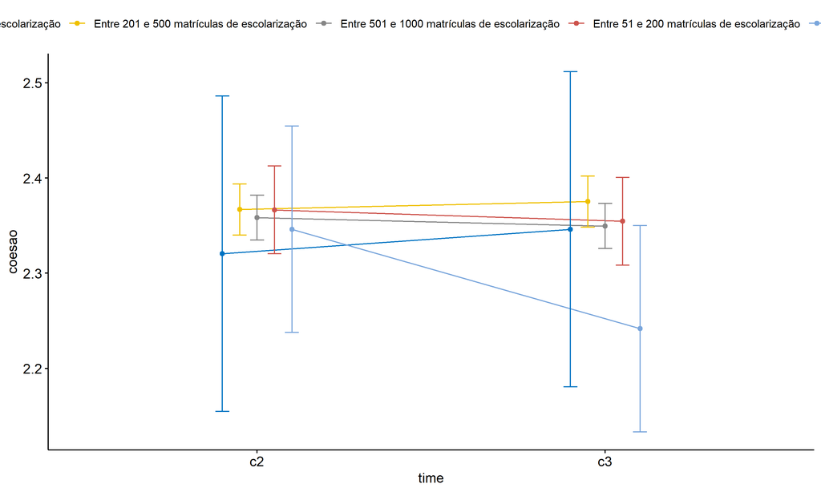

```r
pwc <- add_xy_position(pwc, x = "time", fun = "mean_se", dodge = 0.25)
pd <- position_dodge(width = 0.25)
ggline(emms, x = "time", y = "emmean", color = "porte",
       palette = c("#0073C2FF","#EFC000FF","#868686FF","#CD534CFF","#7AA6DCFF"),
       position = pd, ylab = "coesao") +
  geom_errorbar(aes(ymin = conf.low, ymax = conf.high, color = porte),
                position = pd, width = 0.2) +
  stat_pvalue_manual(pwc, hide.ns = T, tip.length = F, linetype = 1)
```

```r
(pwc <- ldat %>% group_by(porte) %>%
    emmeans_test(coesao ~ time, detailed = T, p.adjust.method = "bonferroni"))
```

```
## # A tibble: 5 × 15
##   porte      term  .y.   group1 group2 null.value estimate     se    df conf.low
## * <fct>      <chr> <chr> <chr>  <chr>       <dbl>    <dbl>  <dbl> <dbl>    <dbl>
## 1 Até 50 ma… time  coes… c2     c3              0 -0.0256  0.119   8074  -0.260
## 2 Entre 201… time  coes… c2     c3              0 -0.00834 0.0193  8074  -0.0463
## 3 Entre 501… time  coes… c2     c3              0  0.00884 0.0170  8074  -0.0245
## 4 Entre 51 … time  coes… c2     c3              0  0.0120  0.0333  8074  -0.0533
## 5 Mais de 1… time  coes… c2     c3              0  0.104   0.0782  8074  -0.0489
## # ℹ 5 more variables: conf.high <dbl>, statistic <dbl>, p <dbl>, p.adj <dbl>,
## #   p.adj.signif <chr>
```

| porte | term | .y. | group1 | group2 | null.value | estimate | se | df | conf.low | conf.high | statistic | p | p.adj | p.adj.signif |
| --- | --- | --- | --- | --- | --- | --- | --- | --- | --- | --- | --- | --- | --- | --- |
| Até 50 matrículas de escolarização | time | coesao | c2 | c3 | 0 | -0.026 | 0.119 | 8074 | -0.260 | 0.209 | -0.215 | 0.830 | 0.830 | ns |
| Entre 201 e 500 matrículas de escolarização | time | coesao | c2 | c3 | 0 | -0.008 | 0.019 | 8074 | -0.046 | 0.030 | -0.432 | 0.666 | 0.666 | ns |
| Entre 501 e 1000 matrículas de escolarização | time | coesao | c2 | c3 | 0 | 0.009 | 0.017 | 8074 | -0.025 | 0.042 | 0.520 | 0.603 | 0.603 | ns |
| Entre 51 e 200 matrículas de escolarização | time | coesao | c2 | c3 | 0 | 0.012 | 0.033 | 8074 | -0.053 | 0.077 | 0.359 | 0.720 | 0.720 | ns |
| Mais de 1000 matrículas de escolarização | time | coesao | c2 | c3 | 0 | 0.104 | 0.078 | 8074 | -0.049 | 0.258 | 1.335 | 0.182 | 0.182 | ns |

```r
(emms <- get_emmeans(pwc))
```

```
## # A tibble: 10 × 8
##    porte                     time  emmean     se    df conf.low conf.high method
##    <fct>                     <fct>  <dbl>  <dbl> <dbl>    <dbl>     <dbl> <chr>
##  1 Até 50 matrículas de esc… c2      2.32 0.0845  8074     2.15      2.49 Emmea…
##  2 Até 50 matrículas de esc… c3      2.35 0.0845  8074     2.18      2.51 Emmea…
##  3 Entre 201 e 500 matrícul… c2      2.37 0.0137  8074     2.34      2.39 Emmea…
##  4 Entre 201 e 500 matrícul… c3      2.38 0.0137  8074     2.35      2.40 Emmea…
##  5 Entre 501 e 1000 matrícu… c2      2.36 0.0120  8074     2.33      2.38 Emmea…
##  6 Entre 501 e 1000 matrícu… c3      2.35 0.0120  8074     2.33      2.37 Emmea…
##  7 Entre 51 e 200 matrícula… c2      2.37 0.0235  8074     2.32      2.41 Emmea…
##  8 Entre 51 e 200 matrícula… c3      2.35 0.0235  8074     2.31      2.40 Emmea…
##  9 Mais de 1000 matrículas … c2      2.35 0.0553  8074     2.24      2.45 Emmea…
## 10 Mais de 1000 matrículas … c3      2.24 0.0553  8074     2.13      2.35 Emmea…
```

| porte | time | emmean | se | df | conf.low | conf.high | method |
| --- | --- | --- | --- | --- | --- | --- | --- |
| Até 50 matrículas de escolarização | c2 | 2.321 | 0.084 | 8074 | 2.155 | 2.486 | Emmeans test |
| Até 50 matrículas de escolarização | c3 | 2.346 | 0.084 | 8074 | 2.181 | 2.512 | Emmeans test |
| Entre 201 e 500 matrículas de escolarização | c2 | 2.367 | 0.014 | 8074 | 2.340 | 2.394 | Emmeans test |
| Entre 201 e 500 matrículas de escolarização | c3 | 2.375 | 0.014 | 8074 | 2.348 | 2.402 | Emmeans test |
| Entre 501 e 1000 matrículas de escolarização | c2 | 2.358 | 0.012 | 8074 | 2.335 | 2.382 | Emmeans test |
| Entre 501 e 1000 matrículas de escolarização | c3 | 2.350 | 0.012 | 8074 | 2.326 | 2.373 | Emmeans test |
| Entre 51 e 200 matrículas de escolarização | c2 | 2.367 | 0.024 | 8074 | 2.320 | 2.413 | Emmeans test |
| Entre 51 e 200 matrículas de escolarização | c3 | 2.355 | 0.024 | 8074 | 2.308 | 2.401 | Emmeans test |
| Mais de 1000 matrículas de escolarização | c2 | 2.346 | 0.055 | 8074 | 2.238 | 2.455 | Emmeans test |
| Mais de 1000 matrículas de escolarização | c3 | 2.242 | 0.055 | 8074 | 2.133 | 2.350 | Emmeans test |

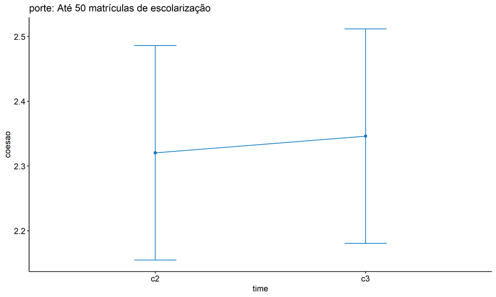

```r
emms.gg <- emms[which(emms$porte == "Até 50 matrículas de escolarização"),]
if (nrow(emms.gg) > 0)
  ggline(emms.gg, x = "time", y = "emmean", color = "#0073C2FF", ylab = "coesao") +
    geom_errorbar(aes(ymin = conf.low, ymax = conf.high),
                  width = 0.2, color = "#0073C2FF") +
    stat_pvalue_manual(
      add_xy_position(pwc[which(pwc$porte == "Até 50 matrículas de escolarização"),],
                      x = "time", fun = "mean_se"),
      hide.ns = T, color = "#0073C2FF", tip.length = F) +
    labs(title = "porte: Até 50 matrículas de escolarização")+
    theme(legend.text = element_blank())
```

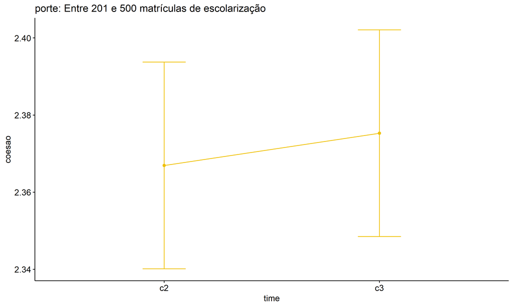

```r
emms.gg <- emms[which(emms$porte == "Entre 201 e 500 matrículas de escolarização"),]
if (nrow(emms.gg) > 0)
  ggline(emms.gg, x = "time", y = "emmean", color = "#EFC000FF", ylab = "coesao") +
    geom_errorbar(aes(ymin = conf.low, ymax = conf.high),
                  width = 0.2, color = "#EFC000FF") +
    stat_pvalue_manual(
      add_xy_position(pwc[which(pwc$porte == "Entre 201 e 500 matrículas de escolarização"),],
                      x = "time", fun = "mean_se"),
      hide.ns = T, color = "#EFC000FF", tip.length = F) +
    labs(title = "porte: Entre 201 e 500 matrículas de escolarização")+
    theme(legend.text = element_blank())
```

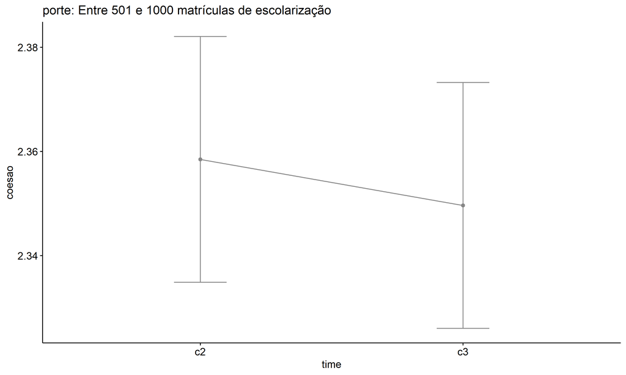

```r
emms.gg <- emms[which(emms$porte == "Entre 501 e 1000 matrículas de escolarização"),]
if (nrow(emms.gg) > 0)
  ggline(emms.gg, x = "time", y = "emmean", color = "#868686FF", ylab = "coesao") +
    geom_errorbar(aes(ymin = conf.low, ymax = conf.high),
                  width = 0.2, color = "#868686FF") +
    stat_pvalue_manual(
      add_xy_position(pwc[which(pwc$porte == "Entre 501 e 1000 matrículas de escolarização"),],
                      x = "time", fun = "mean_se"),
      hide.ns = T, color = "#868686FF", tip.length = F) +
    labs(title = "porte: Entre 501 e 1000 matrículas de escolarização")+
    theme(legend.text = element_blank())
```

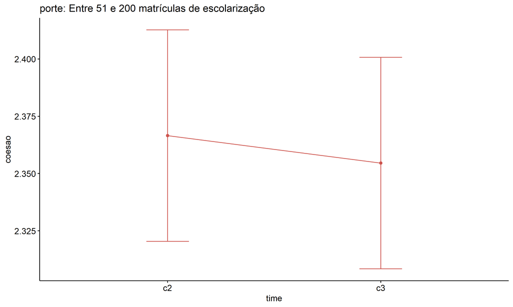

```r
emms.gg <- emms[which(emms$porte == "Entre 51 e 200 matrículas de escolarização"),]
if (nrow(emms.gg) > 0)
  ggline(emms.gg, x = "time", y = "emmean", color = "#CD534CFF", ylab = "coesao") +
    geom_errorbar(aes(ymin = conf.low, ymax = conf.high),
                  width = 0.2, color = "#CD534CFF") +
    stat_pvalue_manual(
      add_xy_position(pwc[which(pwc$porte == "Entre 51 e 200 matrículas de escolarização"),],
                      x = "time", fun = "mean_se"),
      hide.ns = T, color = "#CD534CFF", tip.length = F) +
    labs(title = "porte: Entre 51 e 200 matrículas de escolarização")+
    theme(legend.text = element_blank())
```

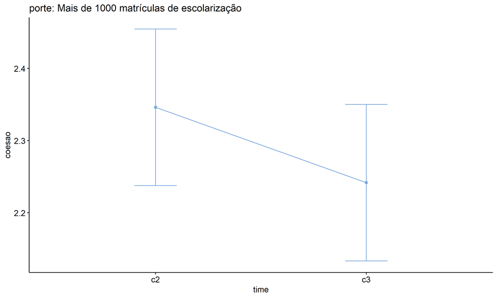

```r
emms.gg <- emms[which(emms$porte == "Mais de 1000 matrículas de escolarização"),]
if (nrow(emms.gg) > 0)
  ggline(emms.gg, x = "time", y = "emmean", color = "#7AA6DCFF", ylab = "coesao") +
    geom_errorbar(aes(ymin = conf.low, ymax = conf.high),
                  width = 0.2, color = "#7AA6DCFF") +
    stat_pvalue_manual(
      add_xy_position(pwc[which(pwc$porte == "Mais de 1000 matrículas de escolarização"),],
                      x = "time", fun = "mean_se"),
      hide.ns = T, color = "#7AA6DCFF", tip.length = F) +
    labs(title = "porte: Mais de 1000 matrículas de escolarização")+
    theme(legend.text = element_blank())
```

## PairWise Computation after removing non.normal data

```r
if (length(non.ids) > 0)
  (pwc2 <- ldat2 %>% group_by(time) %>%
     emmeans_test(coesao ~ porte, detailed = T, p.adjust.method = "bonferroni"))
```

```
## # A tibble: 20 × 15
##    time  term  .y.    group1    group2 null.value estimate     se    df conf.low
##  * <fct> <chr> <chr>  <chr>     <chr>       <dbl>    <dbl>  <dbl> <dbl>    <dbl>
##  1 c2    porte coesao Até 50 m… Entre…          0 -3.88e-2 0.0942  8060 -0.223
##  2 c2    porte coesao Até 50 m… Entre…          0 -3.04e-2 0.0940  8060 -0.215
##  3 c2    porte coesao Até 50 m… Entre…          0 -3.84e-2 0.0961  8060 -0.227
##  4 c2    porte coesao Até 50 m… Mais …          0 -1.80e-2 0.108   8060 -0.230
##  5 c2    porte coesao Entre 20… Entre…          0  8.45e-3 0.0182  8060 -0.0272
##  6 c2    porte coesao Entre 20… Entre…          0  4.02e-4 0.0272  8060 -0.0529
##  7 c2    porte coesao Entre 20… Mais …          0  2.08e-2 0.0569  8060 -0.0908
##  8 c2    porte coesao Entre 50… Entre…          0 -8.05e-3 0.0264  8060 -0.0599
##  9 c2    porte coesao Entre 50… Mais …          0  1.23e-2 0.0566  8060 -0.0985
## 10 c2    porte coesao Entre 51… Mais …          0  2.04e-2 0.0601  8060 -0.0974
## 11 c3    porte coesao Até 50 m… Entre…          0 -1.10e-1 0.0942  8060 -0.294
## 12 c3    porte coesao Até 50 m… Entre…          0 -8.40e-2 0.0940  8060 -0.268
## 13 c3    porte coesao Até 50 m… Entre…          0 -8.90e-2 0.0961  8060 -0.277
## 14 c3    porte coesao Até 50 m… Mais …          0  2.39e-2 0.108   8060 -0.189
## 15 c3    porte coesao Entre 20… Entre…          0  2.56e-2 0.0182  8060 -0.0100
## 16 c3    porte coesao Entre 20… Entre…          0  2.07e-2 0.0272  8060 -0.0326
## 17 c3    porte coesao Entre 20… Mais …          0  1.34e-1 0.0569  8060  0.0219
## 18 c3    porte coesao Entre 50… Entre…          0 -4.95e-3 0.0264  8060 -0.0567
## 19 c3    porte coesao Entre 50… Mais …          0  1.08e-1 0.0566  8060 -0.00299
## 20 c3    porte coesao Entre 51… Mais …          0  1.13e-1 0.0601  8060 -0.00492
## # ℹ 5 more variables: conf.high <dbl>, statistic <dbl>, p <dbl>, p.adj <dbl>,
## #   p.adj.signif <chr>
```

| time | term | .y. | group1 | group2 | null.value | estimate | se | df | conf.low | conf.high | statistic | p | p.adj | p.adj.signif |
| --- | --- | --- | --- | --- | --- | --- | --- | --- | --- | --- | --- | --- | --- | --- |
| c2 | porte | coesao | Até 50 matrículas de escolarização | Entre 201 e 500 matrículas de escolarização | 0 | -0.039 | 0.094 | 8060 | -0.223 | 0.146 | -0.412 | 0.680 | 1.000 | ns |
| c2 | porte | coesao | Até 50 matrículas de escolarização | Entre 501 e 1000 matrículas de escolarização | 0 | -0.030 | 0.094 | 8060 | -0.215 | 0.154 | -0.323 | 0.747 | 1.000 | ns |
| c2 | porte | coesao | Até 50 matrículas de escolarização | Entre 51 e 200 matrículas de escolarização | 0 | -0.038 | 0.096 | 8060 | -0.227 | 0.150 | -0.400 | 0.689 | 1.000 | ns |
| c2 | porte | coesao | Até 50 matrículas de escolarização | Mais de 1000 matrículas de escolarização | 0 | -0.018 | 0.108 | 8060 | -0.230 | 0.194 | -0.166 | 0.868 | 1.000 | ns |
| c2 | porte | coesao | Entre 201 e 500 matrículas de escolarização | Entre 501 e 1000 matrículas de escolarização | 0 | 0.008 | 0.018 | 8060 | -0.027 | 0.044 | 0.464 | 0.642 | 1.000 | ns |
| c2 | porte | coesao | Entre 201 e 500 matrículas de escolarização | Entre 51 e 200 matrículas de escolarização | 0 | 0.000 | 0.027 | 8060 | -0.053 | 0.054 | 0.015 | 0.988 | 1.000 | ns |
| c2 | porte | coesao | Entre 201 e 500 matrículas de escolarização | Mais de 1000 matrículas de escolarização | 0 | 0.021 | 0.057 | 8060 | -0.091 | 0.132 | 0.365 | 0.715 | 1.000 | ns |
| c2 | porte | coesao | Entre 501 e 1000 matrículas de escolarização | Entre 51 e 200 matrículas de escolarização | 0 | -0.008 | 0.026 | 8060 | -0.060 | 0.044 | -0.305 | 0.761 | 1.000 | ns |
| c2 | porte | coesao | Entre 501 e 1000 matrículas de escolarização | Mais de 1000 matrículas de escolarização | 0 | 0.012 | 0.057 | 8060 | -0.099 | 0.123 | 0.218 | 0.827 | 1.000 | ns |
| c2 | porte | coesao | Entre 51 e 200 matrículas de escolarização | Mais de 1000 matrículas de escolarização | 0 | 0.020 | 0.060 | 8060 | -0.097 | 0.138 | 0.339 | 0.734 | 1.000 | ns |
| c3 | porte | coesao | Até 50 matrículas de escolarização | Entre 201 e 500 matrículas de escolarização | 0 | -0.110 | 0.094 | 8060 | -0.294 | 0.075 | -1.164 | 0.244 | 1.000 | ns |
| c3 | porte | coesao | Até 50 matrículas de escolarização | Entre 501 e 1000 matrículas de escolarização | 0 | -0.084 | 0.094 | 8060 | -0.268 | 0.100 | -0.894 | 0.371 | 1.000 | ns |
| c3 | porte | coesao | Até 50 matrículas de escolarização | Entre 51 e 200 matrículas de escolarização | 0 | -0.089 | 0.096 | 8060 | -0.277 | 0.099 | -0.925 | 0.355 | 1.000 | ns |
| c3 | porte | coesao | Até 50 matrículas de escolarização | Mais de 1000 matrículas de escolarização | 0 | 0.024 | 0.108 | 8060 | -0.189 | 0.236 | 0.220 | 0.826 | 1.000 | ns |
| c3 | porte | coesao | Entre 201 e 500 matrículas de escolarização | Entre 501 e 1000 matrículas de escolarização | 0 | 0.026 | 0.018 | 8060 | -0.010 | 0.061 | 1.409 | 0.159 | 1.000 | ns |
| c3 | porte | coesao | Entre 201 e 500 matrículas de escolarização | Entre 51 e 200 matrículas de escolarização | 0 | 0.021 | 0.027 | 8060 | -0.033 | 0.074 | 0.761 | 0.447 | 1.000 | ns |
| c3 | porte | coesao | Entre 201 e 500 matrículas de escolarização | Mais de 1000 matrículas de escolarização | 0 | 0.134 | 0.057 | 8060 | 0.022 | 0.245 | 2.345 | 0.019 | 0.190 | ns |
| c3 | porte | coesao | Entre 501 e 1000 matrículas de escolarização | Entre 51 e 200 matrículas de escolarização | 0 | -0.005 | 0.026 | 8060 | -0.057 | 0.047 | -0.187 | 0.852 | 1.000 | ns |
| c3 | porte | coesao | Entre 501 e 1000 matrículas de escolarização | Mais de 1000 matrículas de escolarização | 0 | 0.108 | 0.057 | 8060 | -0.003 | 0.219 | 1.907 | 0.057 | 0.565 | ns |
| c3 | porte | coesao | Entre 51 e 200 matrículas de escolarização | Mais de 1000 matrículas de escolarização | 0 | 0.113 | 0.060 | 8060 | -0.005 | 0.231 | 1.878 | 0.060 | 0.604 | ns |

```r
if (length(non.ids) > 0)
  (emms2 <- get_emmeans(pwc2))
```

```
## # A tibble: 10 × 8
##    time  porte                     emmean     se    df conf.low conf.high method
##    <fct> <fct>                      <dbl>  <dbl> <dbl>    <dbl>     <dbl> <chr>
##  1 c2    Até 50 matrículas de esc…   2.33 0.0932  8060     2.15      2.51 Emmea…
##  2 c2    Entre 201 e 500 matrícul…   2.37 0.0137  8060     2.34      2.39 Emmea…
##  3 c2    Entre 501 e 1000 matrícu…   2.36 0.0120  8060     2.33      2.38 Emmea…
##  4 c2    Entre 51 e 200 matrícula…   2.37 0.0235  8060     2.32      2.41 Emmea…
##  5 c2    Mais de 1000 matrículas …   2.35 0.0553  8060     2.24      2.45 Emmea…
##  6 c3    Até 50 matrículas de esc…   2.27 0.0932  8060     2.08      2.45 Emmea…
##  7 c3    Entre 201 e 500 matrícul…   2.38 0.0137  8060     2.35      2.40 Emmea…
##  8 c3    Entre 501 e 1000 matrícu…   2.35 0.0120  8060     2.33      2.37 Emmea…
##  9 c3    Entre 51 e 200 matrícula…   2.35 0.0235  8060     2.31      2.40 Emmea…
## 10 c3    Mais de 1000 matrículas …   2.24 0.0553  8060     2.13      2.35 Emmea…
```

| time | porte | emmean | se | df | conf.low | conf.high | method |
| --- | --- | --- | --- | --- | --- | --- | --- |
| c2 | Até 50 matrículas de escolarização | 2.328 | 0.093 | 8060 | 2.145 | 2.511 | Emmeans test |
| c2 | Entre 201 e 500 matrículas de escolarização | 2.367 | 0.014 | 8060 | 2.340 | 2.394 | Emmeans test |
| c2 | Entre 501 e 1000 matrículas de escolarização | 2.358 | 0.012 | 8060 | 2.335 | 2.382 | Emmeans test |
| c2 | Entre 51 e 200 matrículas de escolarização | 2.367 | 0.024 | 8060 | 2.320 | 2.413 | Emmeans test |
| c2 | Mais de 1000 matrículas de escolarização | 2.346 | 0.055 | 8060 | 2.238 | 2.454 | Emmeans test |
| c3 | Até 50 matrículas de escolarização | 2.266 | 0.093 | 8060 | 2.083 | 2.448 | Emmeans test |
| c3 | Entre 201 e 500 matrículas de escolarização | 2.375 | 0.014 | 8060 | 2.348 | 2.402 | Emmeans test |
| c3 | Entre 501 e 1000 matrículas de escolarização | 2.350 | 0.012 | 8060 | 2.326 | 2.373 | Emmeans test |
| c3 | Entre 51 e 200 matrículas de escolarização | 2.355 | 0.024 | 8060 | 2.308 | 2.401 | Emmeans test |
| c3 | Mais de 1000 matrículas de escolarização | 2.242 | 0.055 | 8060 | 2.133 | 2.350 | Emmeans test |

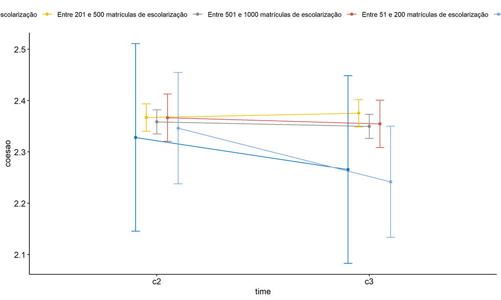

```r
if (length(non.ids) > 0) {
  pwc2 <- add_xy_position(pwc2, x = "time", fun = "mean_se", dodge = 0.25)
  pd2 <- position_dodge(width = 0.25)

  ggline(emms2, x = "time", y = "emmean", color = "porte",
         palette = c("#0073C2FF","#EFC000FF","#868686FF","#CD534CFF","#7AA6DCFF"),
         position = pd, ylab = "coesao") +
    geom_errorbar(aes(ymin = conf.low, ymax = conf.high, color = porte),
                position = pd, width = 0.2) +
    stat_pvalue_manual(pwc2, hide.ns = T, tip.length = F, linetype = 1)
}
```

```r
if (length(non.ids) > 0)
  (pwc2 <- ldat2 %>% group_by(porte) %>%
     emmeans_test(coesao ~ time, detailed = T, p.adjust.method = "bonferroni"))
```

```
## # A tibble: 5 × 15
##   porte      term  .y.   group1 group2 null.value estimate     se    df conf.low
## * <fct>      <chr> <chr> <chr>  <chr>       <dbl>    <dbl>  <dbl> <dbl>    <dbl>
## 1 Até 50 ma… time  coes… c2     c3              0  0.0625  0.132   8060  -0.196
## 2 Entre 201… time  coes… c2     c3              0 -0.00834 0.0193  8060  -0.0462
## 3 Entre 501… time  coes… c2     c3              0  0.00884 0.0170  8060  -0.0245
## 4 Entre 51 … time  coes… c2     c3              0  0.0120  0.0333  8060  -0.0533
## 5 Mais de 1… time  coes… c2     c3              0  0.104   0.0782  8060  -0.0488
## # ℹ 5 more variables: conf.high <dbl>, statistic <dbl>, p <dbl>, p.adj <dbl>,
## #   p.adj.signif <chr>
```

| porte | term | .y. | group1 | group2 | null.value | estimate | se | df | conf.low | conf.high | statistic | p | p.adj | p.adj.signif |
| --- | --- | --- | --- | --- | --- | --- | --- | --- | --- | --- | --- | --- | --- | --- |
| Até 50 matrículas de escolarização | time | coesao | c2 | c3 | 0 | 0.063 | 0.132 | 8060 | -0.196 | 0.321 | 0.474 | 0.635 | 0.635 | ns |
| Entre 201 e 500 matrículas de escolarização | time | coesao | c2 | c3 | 0 | -0.008 | 0.019 | 8060 | -0.046 | 0.030 | -0.432 | 0.666 | 0.666 | ns |
| Entre 501 e 1000 matrículas de escolarização | time | coesao | c2 | c3 | 0 | 0.009 | 0.017 | 8060 | -0.024 | 0.042 | 0.520 | 0.603 | 0.603 | ns |
| Entre 51 e 200 matrículas de escolarização | time | coesao | c2 | c3 | 0 | 0.012 | 0.033 | 8060 | -0.053 | 0.077 | 0.359 | 0.719 | 0.719 | ns |
| Mais de 1000 matrículas de escolarização | time | coesao | c2 | c3 | 0 | 0.104 | 0.078 | 8060 | -0.049 | 0.258 | 1.336 | 0.182 | 0.182 | ns |

```r
if (length(non.ids) > 0)
  (emms2 <- get_emmeans(pwc2))
```

```
## # A tibble: 10 × 8
##    porte                     time  emmean     se    df conf.low conf.high method
##    <fct>                     <fct>  <dbl>  <dbl> <dbl>    <dbl>     <dbl> <chr>
##  1 Até 50 matrículas de esc… c2      2.33 0.0932  8060     2.15      2.51 Emmea…
##  2 Até 50 matrículas de esc… c3      2.27 0.0932  8060     2.08      2.45 Emmea…
##  3 Entre 201 e 500 matrícul… c2      2.37 0.0137  8060     2.34      2.39 Emmea…
##  4 Entre 201 e 500 matrícul… c3      2.38 0.0137  8060     2.35      2.40 Emmea…
##  5 Entre 501 e 1000 matrícu… c2      2.36 0.0120  8060     2.33      2.38 Emmea…
##  6 Entre 501 e 1000 matrícu… c3      2.35 0.0120  8060     2.33      2.37 Emmea…
##  7 Entre 51 e 200 matrícula… c2      2.37 0.0235  8060     2.32      2.41 Emmea…
##  8 Entre 51 e 200 matrícula… c3      2.35 0.0235  8060     2.31      2.40 Emmea…
##  9 Mais de 1000 matrículas … c2      2.35 0.0553  8060     2.24      2.45 Emmea…
## 10 Mais de 1000 matrículas … c3      2.24 0.0553  8060     2.13      2.35 Emmea…
```

| porte | time | emmean | se | df | conf.low | conf.high | method |
| --- | --- | --- | --- | --- | --- | --- | --- |
| Até 50 matrículas de escolarização | c2 | 2.328 | 0.093 | 8060 | 2.145 | 2.511 | Emmeans test |
| Até 50 matrículas de escolarização | c3 | 2.266 | 0.093 | 8060 | 2.083 | 2.448 | Emmeans test |
| Entre 201 e 500 matrículas de escolarização | c2 | 2.367 | 0.014 | 8060 | 2.340 | 2.394 | Emmeans test |
| Entre 201 e 500 matrículas de escolarização | c3 | 2.375 | 0.014 | 8060 | 2.348 | 2.402 | Emmeans test |
| Entre 501 e 1000 matrículas de escolarização | c2 | 2.358 | 0.012 | 8060 | 2.335 | 2.382 | Emmeans test |
| Entre 501 e 1000 matrículas de escolarização | c3 | 2.350 | 0.012 | 8060 | 2.326 | 2.373 | Emmeans test |
| Entre 51 e 200 matrículas de escolarização | c2 | 2.367 | 0.024 | 8060 | 2.320 | 2.413 | Emmeans test |
| Entre 51 e 200 matrículas de escolarização | c3 | 2.355 | 0.024 | 8060 | 2.308 | 2.401 | Emmeans test |
| Mais de 1000 matrículas de escolarização | c2 | 2.346 | 0.055 | 8060 | 2.238 | 2.454 | Emmeans test |
| Mais de 1000 matrículas de escolarização | c3 | 2.242 | 0.055 | 8060 | 2.133 | 2.350 | Emmeans test |

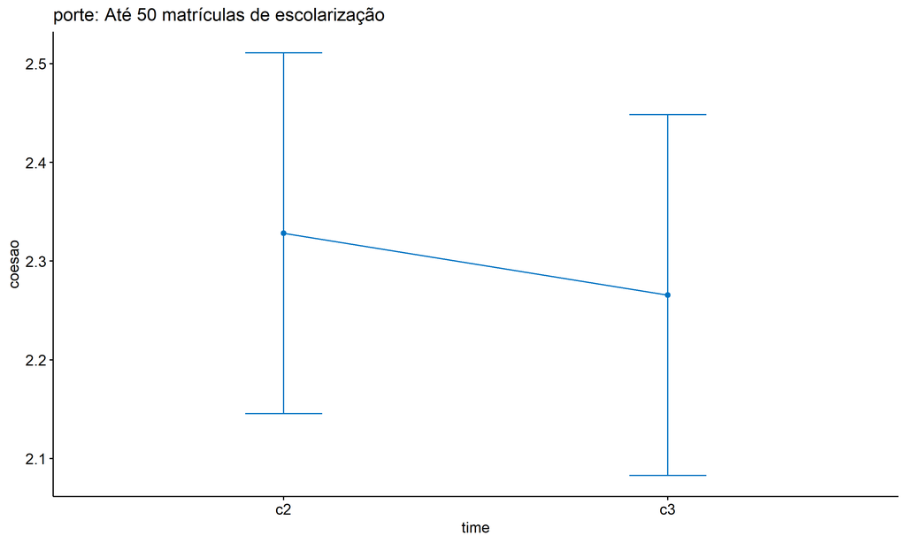

```r
if (length(non.ids) > 0) {
  emms.gg <- emms2[which(emms2$porte == "Até 50 matrículas de escolarização"),]
  if (nrow(emms.gg) > 0)
    ggline(emms.gg, x = "time", y = "emmean", color = "#0073C2FF", ylab = "coesao") +
    geom_errorbar(aes(ymin = conf.low, ymax = conf.high),
                  width = 0.2, color = "#0073C2FF") +
    stat_pvalue_manual(
      add_xy_position(pwc[which(pwc$porte == "Até 50 matrículas de escolarização"),],
                      x = "time", fun = "mean_se"),
      hide.ns = T, color = "#0073C2FF", tip.length = F) +
    labs(title = "porte: Até 50 matrículas de escolarização") +
    theme(legend.text = element_blank())
}
```

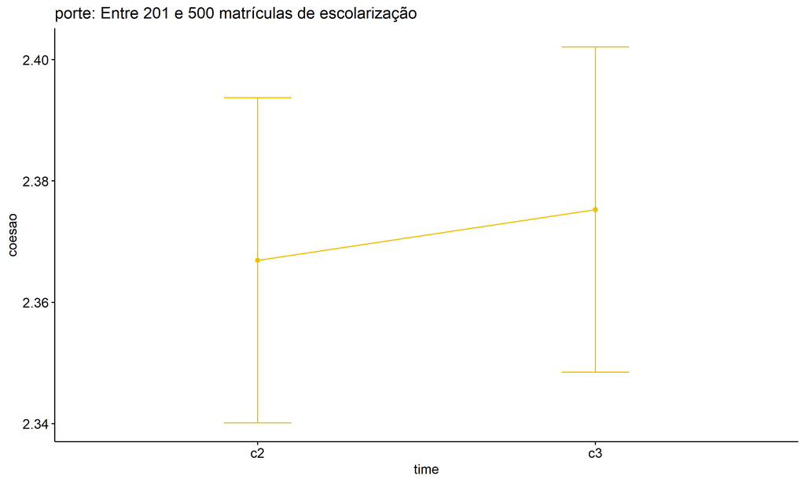

```r
if (length(non.ids) > 0) {
  emms.gg <- emms2[which(emms2$porte == "Entre 201 e 500 matrículas de escolarização"),]
  if (nrow(emms.gg) > 0)
    ggline(emms.gg, x = "time", y = "emmean", color = "#EFC000FF", ylab = "coesao") +
    geom_errorbar(aes(ymin = conf.low, ymax = conf.high),
                  width = 0.2, color = "#EFC000FF") +
    stat_pvalue_manual(
      add_xy_position(pwc[which(pwc$porte == "Entre 201 e 500 matrículas de escolarização"),],
                      x = "time", fun = "mean_se"),
      hide.ns = T, color = "#EFC000FF", tip.length = F) +
    labs(title = "porte: Entre 201 e 500 matrículas de escolarização") +
    theme(legend.text = element_blank())
}
```

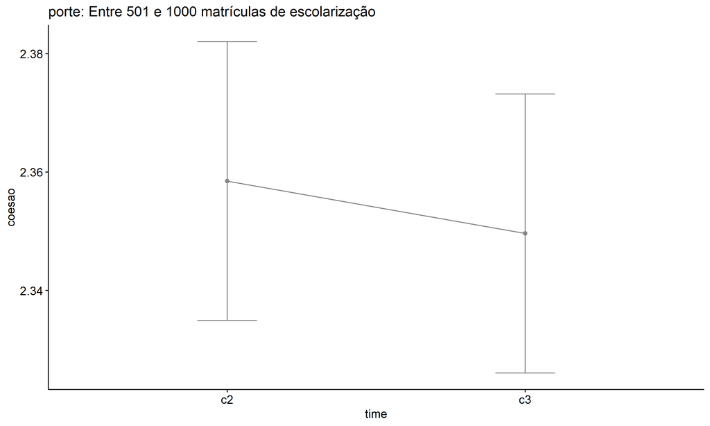

```r
if (length(non.ids) > 0) {
  emms.gg <- emms2[which(emms2$porte == "Entre 501 e 1000 matrículas de escolarização"),]
  if (nrow(emms.gg) > 0)
    ggline(emms.gg, x = "time", y = "emmean", color = "#868686FF", ylab = "coesao") +
    geom_errorbar(aes(ymin = conf.low, ymax = conf.high),
                  width = 0.2, color = "#868686FF") +
    stat_pvalue_manual(
      add_xy_position(pwc[which(pwc$porte == "Entre 501 e 1000 matrículas de escolarização"),],
                      x = "time", fun = "mean_se"),
      hide.ns = T, color = "#868686FF", tip.length = F) +
    labs(title = "porte: Entre 501 e 1000 matrículas de escolarização") +
    theme(legend.text = element_blank())
}
```

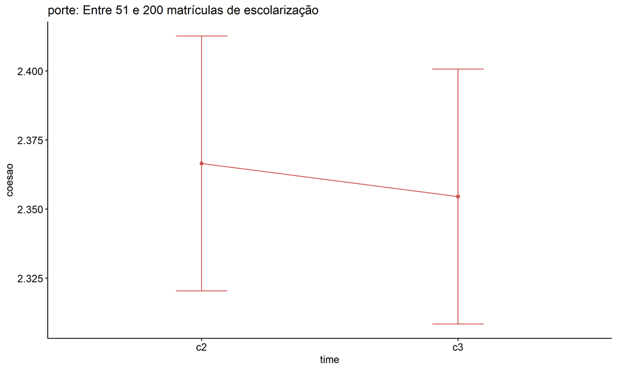

```r
if (length(non.ids) > 0) {
  emms.gg <- emms2[which(emms2$porte == "Entre 51 e 200 matrículas de escolarização"),]
  if (nrow(emms.gg) > 0)
    ggline(emms.gg, x = "time", y = "emmean", color = "#CD534CFF", ylab = "coesao") +
    geom_errorbar(aes(ymin = conf.low, ymax = conf.high),
                  width = 0.2, color = "#CD534CFF") +
    stat_pvalue_manual(
      add_xy_position(pwc[which(pwc$porte == "Entre 51 e 200 matrículas de escolarização"),],
                      x = "time", fun = "mean_se"),
      hide.ns = T, color = "#CD534CFF", tip.length = F) +
    labs(title = "porte: Entre 51 e 200 matrículas de escolarização") +
    theme(legend.text = element_blank())
}
```

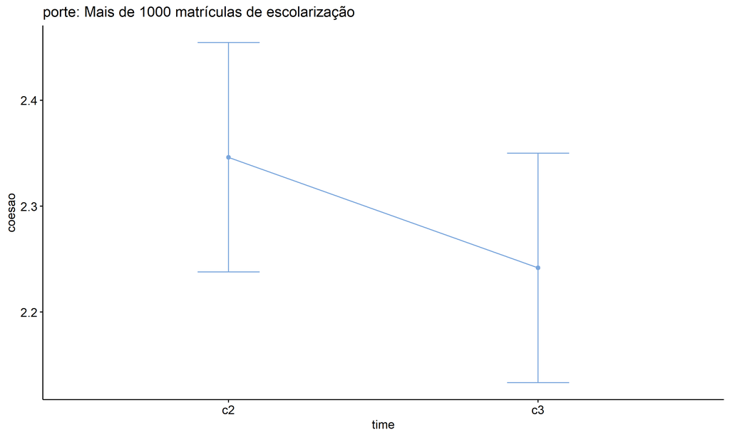

```r
if (length(non.ids) > 0) {
  emms.gg <- emms2[which(emms2$porte == "Mais de 1000 matrículas de escolarização"),]
  if (nrow(emms.gg) > 0)
    ggline(emms.gg, x = "time", y = "emmean", color = "#7AA6DCFF", ylab = "coesao") +
    geom_errorbar(aes(ymin = conf.low, ymax = conf.high),
                  width = 0.2, color = "#7AA6DCFF") +
    stat_pvalue_manual(
      add_xy_position(pwc[which(pwc$porte == "Mais de 1000 matrículas de escolarização"),],
                      x = "time", fun = "mean_se"),
      hide.ns = T, color = "#7AA6DCFF", tip.length = F) +
    labs(title = "porte: Mais de 1000 matrículas de escolarização") +
    theme(legend.text = element_blank())
}
```